# Chicago Crime Prediction

## Package Importing

In this project, we will be utilizing the `tidyverse` and `lubridate` packages for data management and data handling.

```r
library(tidyverse)
library(lubridate)
library(randomForest)
library(caret)
require(caTools)
```

## Hypotheses

1. The likelihood of an arrest can be calculated from the type of crime and weather features
2. The likelihood of an arrest can be calculated from the type of crime and the crime’s location in relation of libraries, parks, and public art
3. Days with inclement weather will have different amounts of the most common crime (Battery and Theft) than days without inclement weather

## Datasets

We have decided to use multiple different datasets for this project, allowing us to pull broader and more impactful relations within our data. Each of the datasets we are using will be imported below, with an explanation and information on each.

### Chicago Crime Dataset

The Chicago Crime dataset contains records of most crimes that the Chicago Police responded to, between the years of 2001 to present, and has been aggregated by the City of Chicago.

The dataset contains nearly 7,500,000 entries, with 22 total features. Features include information about the date and location of the crime, as well as information about the type of crime and description of events. During this experiment, we will primarily be using the `Primary Type` feature (listing the type of crime) as a target variable, in order to determine if there are external factors to the types of crimes being predicted. As a note, we have only selected a more recent subset of the data, to focus on the current state of crime in the city, and to make the data more workable.

This dataset can be sourced from the [City of Chicago website](https://data.cityofchicago.org/Public-Safety/Crimes-2001-to-Present/ijzp-q8t2).

```r
crime_data <- read_csv(
  "data/chicago-crime-dataset.csv",
  col_names = TRUE,
  locale = locale("en", tz="US/Central"),
  na = c("", "NA"),
  skip_empty_rows = TRUE,
  show_col_types = FALSE,
)
```

### NOAA Chicago Weather Dataset

This dataset contains information about the location of the weather station taking the data, information about average temperature, wind speeds, precipitation, snow, and other inclement weather. We will be using this dataset to determine whether or not certain weather events have an impact on the types of crimes being committed, and if more severe crimes are more likely during certain weather events.

This dataset can be sourced from the [NOAA website](https://www.weather.gov/wrh/Climate?wfo=lot).

```r
weather_data <- read_csv(
  "data/noaa-chicago-weather.csv",
  col_names = TRUE,
  locale = locale("en", tz="US/Central"),
  na = c("", "NA"),
  skip_empty_rows = TRUE,
  show_col_types = FALSE,
)
```

### Chicago Park Dataset

The Chicago Park dataset contains over 4300 entries, corresponding to different facilities and locations of public parks in the Greater Chicago area. All entries were recorded and distributed by the City of Chicago.

This dataset contains locations and boundaries of the public parks within the Chicago area, along with the facilities located inside of the parks (such as tennis courts, pools, soccer fields, etc). In addition to this, the dataset contains information about the park ID internal to the City of Chicago’s records, as well as the park name. We will be using this dataset to determine whether or not certain parks are correlated to the severity and/or rate of crimes in their area.

This dataset can be sourced from the [City of Chicago website](https://data.cityofchicago.org/Parks-Recreation/Parks-Chicago-Park-District-Facilities-current-/5yyk-qt9y).

```r
park_data <- read_csv(
  "data/chicago-parks-data.csv",
  col_names = TRUE,
  locale = locale("en", tz="US/Central"),
  na = c("", "NA"),
  skip_empty_rows = TRUE,
  show_col_types = FALSE,
)
```

### Chicago Library Dataset

The Chicago Library dataset contains over 80 entries of libraries in the Chicago area. It has been aggregated and distributed by the City of Chicago.

This dataset contains location data (latitude, longitude, and address) for libraries in the Chicago area, as well as the library name, hours of operation, and contact information. We will be using this dataset to determine whether or not certain libraries are correlated to the severity and/or rates of crimes in their area.

This dataset can be sourced from the [City of Chicago website](https://data.cityofchicago.org/Education/Libraries-Locations-Hours-and-Contact-Information-/wa2i-tm5d).

```r
library_data <- read_csv(
  "data/chicago-libraries-data.csv",
  col_names = TRUE,
  locale = locale("en", tz="US/Central"),
  na = c("", "NA"),
  skip_empty_rows = TRUE,
  show_col_types = FALSE,
)
```

### Chicago Public Art Dataset

The Chicago Public Art dataset contains nearly 200 entries of public art locations in Chicago parks. This dataset has been aggregated and distributed by the City of Chicago.

This dataset contains information about the parks containing the artwork, the type of art, the artist, the owner, and latitude/longitude location of the art piece. We will be using it to determine if there is any difference in the types of crimes, or if more severe crimes are committed more/less often within close proximity to public art establishments.

This dataset can be sourced from the [City of Chicago website](https://data.cityofchicago.org/Parks-Recreation/Parks-Public-Art/sj6t-9cju/data).

```r
art_data <- read_csv(
  "data/chicago-public-art-data.csv",
  col_names = TRUE,
  locale = locale("en", tz="US/Central"),
  na = c("", "NA"),
  skip_empty_rows = TRUE,
  show_col_types = FALSE,
)
```

## Data Preprocessing

In this section, we pre-process the data before testing and modelling on it. This includes removing un-needed columns in the data, as well as combining the data into a single, usable source.

### Data Cleaning

```r
cleaned_crime_data <- select(crime_data, -c(ID,'Case Number' , Block, 'X Coordinate', 'Y Coordinate', Year, 'Updated On', Location))
cleaned_crime_data$DateTime <- mdy_hms(cleaned_crime_data$Date)
cleaned_crime_data$Date <- date(cleaned_crime_data$DateTime)
cleaned_crime_data <- cleaned_crime_data %>%
  drop_na() %>%
  filter(Date > "2020-01-01")

cleaned_crime_data$Latitude <- as.numeric((cleaned_crime_data$Latitude))
cleaned_crime_data$Longitude <- as.numeric((cleaned_crime_data$Longitude))

cleaned_crime_data$IUCR <- as.factor(cleaned_crime_data$IUCR)
cleaned_crime_data$`Primary Type` <- as.factor(cleaned_crime_data$`Primary Type`)
cleaned_crime_data$Description <- as.factor(cleaned_crime_data$Description)
cleaned_crime_data$`Location Description` <- as.factor(cleaned_crime_data$`Location Description`)
cleaned_crime_data$`FBI Code` <- as.factor(cleaned_crime_data$`FBI Code`)
```

```r
cleaned_weather_data <- select(weather_data, -c(STATION, NAME, LATITUDE, LONGITUDE, ELEVATION))
cleaned_weather_data$DATE <- mdy(cleaned_weather_data$DATE)
cleaned_weather_data <- cleaned_weather_data %>%
  rename(Date=DATE,
         Fog=WT01,
         Heavy_Fog=WT02,
         Thunder=WT03,
         Ice_Rain=WT04,
         Hail=WT05,
         Glaze=WT06,
         Dust=WT07,
         Smoke=WT08,
         Blowing_Snow=WT09,
         Tornado=WT10,
         High_Winds=WT11,
         Mist=WT13,
         Drizzle=WT14,
         Freezing_Drizzle=WT15,
         Rain=WT16,
         Freezing_Rain=WT17,
         Snow_Precip=WT18,
         Unknown_Precip=WT19,
         Ground_Fog=WT21,
         Ice_Fog=WT22,
         Thunder_2=WV03,
         Rain_Snow_Shower=WV20)

cleaned_weather_data <- cleaned_weather_data %>%
  mutate(Fog=ifelse(is.na(Fog), 0, Fog),
         Heavy_Fog=ifelse(is.na(Heavy_Fog), 0, Heavy_Fog),
         Thunder=ifelse(is.na(Thunder), 0, Thunder),
         Ice_Rain=ifelse(is.na(Ice_Rain), 0, Ice_Rain),
         Hail=ifelse(is.na(Hail), 0, Hail),
         Glaze=ifelse(is.na(Glaze), 0, Glaze),
         Dust=ifelse(is.na(Dust), 0, Dust),
         Smoke=ifelse(is.na(Smoke), 0, Smoke),
         Blowing_Snow=ifelse(is.na(Blowing_Snow), 0, Blowing_Snow),
         Tornado=ifelse(is.na(Tornado), 0, Tornado),
         High_Winds=ifelse(is.na(High_Winds), 0, High_Winds),
         Mist=ifelse(is.na(Mist), 0, Mist),
         Drizzle=ifelse(is.na(Drizzle), 0, Drizzle),
         Freezing_Drizzle=ifelse(is.na(Freezing_Drizzle), 0, Freezing_Drizzle),
         Rain=ifelse(is.na(Rain), 0, Rain),
         Freezing_Rain=ifelse(is.na(Freezing_Rain), 0, Freezing_Rain),
         Snow_Precip=ifelse(is.na(Snow_Precip), 0, Snow_Precip),
         Unknown_Precip=ifelse(is.na(Unknown_Precip), 0, Unknown_Precip),
         Ground_Fog=ifelse(is.na(Ground_Fog), 0, Ground_Fog),
         Ice_Fog=ifelse(is.na(Ice_Fog), 0, Ice_Fog),
         Thunder_2=ifelse(is.na(Thunder_2), 0, Thunder_2),
         Rain_Snow_Shower=ifelse(is.na(Rain_Snow_Shower), 0, Rain_Snow_Shower))

cleaned_weather_data$Fog <- as.logical(cleaned_weather_data$Fog)
cleaned_weather_data$Heavy_Fog <- as.logical(cleaned_weather_data$Heavy_Fog)
cleaned_weather_data$Thunder <- as.logical(cleaned_weather_data$Thunder)
cleaned_weather_data$Ice_Rain <- as.logical(cleaned_weather_data$Ice_Rain)
cleaned_weather_data$Hail <- as.logical(cleaned_weather_data$Hail)
cleaned_weather_data$Glaze <- as.logical(cleaned_weather_data$Glaze)
cleaned_weather_data$Dust <- as.logical(cleaned_weather_data$Dust)
cleaned_weather_data$Smoke <- as.logical(cleaned_weather_data$Smoke)
cleaned_weather_data$Blowing_Snow <- as.logical(cleaned_weather_data$Blowing_Snow)
cleaned_weather_data$Tornado <- as.logical(cleaned_weather_data$Tornado)
cleaned_weather_data$High_Winds <- as.logical(cleaned_weather_data$High_Winds)
cleaned_weather_data$Mist <- as.logical(cleaned_weather_data$Mist)
cleaned_weather_data$Drizzle <- as.logical(cleaned_weather_data$Drizzle)
cleaned_weather_data$Freezing_Drizzle <- as.logical(cleaned_weather_data$Freezing_Drizzle)
cleaned_weather_data$Rain <- as.logical(cleaned_weather_data$Rain)
cleaned_weather_data$Freezing_Rain <- as.logical(cleaned_weather_data$Freezing_Rain)
cleaned_weather_data$Snow_Precip <- as.logical(cleaned_weather_data$Snow_Precip)
cleaned_weather_data$Unknown_Precip <- as.logical(cleaned_weather_data$Unknown_Precip)
cleaned_weather_data$Ground_Fog <- as.logical(cleaned_weather_data$Ground_Fog)
cleaned_weather_data$Ice_Fog <- as.logical(cleaned_weather_data$Ice_Fog)
cleaned_weather_data$Thunder_2 <- as.logical(cleaned_weather_data$Thunder_2)
cleaned_weather_data$Rain_Snow_Shower <- as.logical(cleaned_weather_data$Rain_Snow_Shower)
```

```r
cleaned_park_data <- select(park_data, -c(OBJECTID, the_geom, GISOBJID))
cleaned_park_data <- rename(cleaned_park_data, Longitude = X_COORD, Latitude = Y_COORD)

cleaned_park_data$Latitude <- as.numeric(cleaned_park_data$Latitude)
cleaned_park_data$Longitude <- as.numeric(cleaned_park_data$Longitude)

cleaned_park_data$PARK_NO <- as.factor(cleaned_park_data$PARK_NO)
cleaned_park_data$PARK <- as.factor(cleaned_park_data$PARK)
cleaned_park_data$FACILITY_N <- as.factor(cleaned_park_data$FACILITY_N)
cleaned_park_data$FACILITY_T <- as.factor(cleaned_park_data$FACILITY_T)
```

```r
cleaned_library_data <- select(library_data, -c("HOURS OF OPERATION", ADDRESS, CITY, STATE, ZIP, PHONE, WEBSITE))
cleaned_library_data$LOCATION <- str_remove_all(cleaned_library_data$LOCATION, "[ \\(\\)]")
cleaned_library_data <- cleaned_library_data %>% separate(LOCATION, c("Latitude", "Longitude"), ",")

cleaned_library_data$Latitude <- as.numeric(cleaned_library_data$Latitude)
cleaned_library_data$Longitude <- as.numeric(cleaned_library_data$Longitude)
```

```r
cleaned_art_data <- select(art_data, -c("X COORDINATE", "Y COORDINATE", LOCATION, OWNER))
cleaned_art_data <- rename(cleaned_art_data, Longitude = LONGITUDE, Latitude = LATITUDE)

cleaned_art_data$Latitude <- as.numeric(cleaned_art_data$Latitude)
cleaned_art_data$Longitude <- as.numeric(cleaned_art_data$Longitude)

cleaned_art_data$`PARK NAME` <- as.factor(cleaned_art_data$`PARK NAME`)
cleaned_art_data$`PARK NUMBER` <- as.factor(cleaned_art_data$`PARK NUMBER`)
cleaned_art_data$ARTIST <- as.factor(cleaned_art_data$ARTIST)
```

### Combining Data

```r
combined_data <- cleaned_crime_data %>% left_join(cleaned_weather_data, by="Date")
combined_data <- select(combined_data, -Date)

# Cleaning up previous data sets in environment
rm(art_data)
rm(crime_data)
rm(library_data)
rm(park_data)
rm(weather_data)
```

#### Adding Nearest Park To Crime

```r
park_locations <-cleaned_park_data %>%
  group_by(PARK_NO) %>%
  summarize_at(vars(Longitude:Latitude), mean)

# Function to calculate the distance between two latitude and longitude values (Haversine Formula)
calculate_distance <- function(row, lat1, long1){
  radius <- 3958.8
  d_lat <- abs(lat1-as.numeric(row["Latitude"])) * pi / 180.0
  d_long <- abs(long1-as.numeric(row["Longitude"])) * pi / 180.0

  temp1 <- (sin(d_lat/2.0)**2) +
    ((cos(lat1*pi/180.0) * cos(as.numeric(row["Latitude"])*pi/180.0)) *
    (sin(d_long/2.0)**2))
  temp2 <- 2 * atan2(sqrt(temp1), sqrt(1.0-temp1))
  return(temp2*radius)
}

# Function that finds the closest park and its distance from each crime row
get_closest_park_function <- function(row){
  park_distances <- apply(park_locations, MARGIN=1, FUN=calculate_distance, lat1=as.numeric(row["Latitude"]), long1=as.numeric(row["Longitude"]))
  closest_park_index <- which.min(park_distances)

  closest_dist <- park_distances[closest_park_index]
  closest_park <- (park_locations %>% slice(closest_park_index))$PARK_NO

  return(c(closest_park, closest_dist))
}


closest_parks <- apply(combined_data, MARGIN=1, FUN=get_closest_park_function)
combined_data <- combined_data %>% add_column(closest_park = closest_parks[1,], park_dist = closest_parks[2,])
```

#### Adding Nearest Library To Crime

```r
# Function that finds the closest library and its distance from each crime row
get_closest_library_function <- function(row){
  library_distances <- apply(cleaned_library_data, MARGIN=1, FUN=calculate_distance, lat1=as.numeric(row["Latitude"]), long1=as.numeric(row["Longitude"]))
  closest_library_index <- which.min(library_distances)

  closest_dist <- library_distances[closest_library_index]
  closest_library <- (cleaned_library_data %>% slice(closest_library_index))$NAME

  return(c(closest_library, closest_dist))
}

closest_libraries <- apply(combined_data, MARGIN=1, FUN=get_closest_library_function)
combined_data <- combined_data %>% add_column(closest_library = closest_libraries[1,], library_dist = closest_libraries[2,])
```

#### Adding Nearest Art To Crime

```r
# Function that finds the closest art and its distance from each crime row
get_closest_art_function <- function(row){
  art_distances <- apply(cleaned_art_data, MARGIN=1, FUN=calculate_distance, lat1=as.numeric(row["Latitude"]), long1=as.numeric(row["Longitude"]))
  closest_art_index <- which.min(art_distances)

  closest_dist <- art_distances[closest_art_index]
  closest_art <- (cleaned_art_data %>% slice(closest_art_index))$`ART`

  return(c(closest_art, closest_dist))
}

closest_artwork <- apply(combined_data, MARGIN=1, FUN=get_closest_art_function)
combined_data <- combined_data %>% add_column(closest_art = closest_artwork[1,], art_dist = closest_artwork[2,])
rm(closest_artwork)
```

```r
combined_data$closest_park <- as.factor(combined_data$closest_park)
combined_data$closest_library <- as.factor(combined_data$closest_library)
combined_data$closest_art <- as.factor(combined_data$closest_art)

combined_data$park_dist <- as.double(combined_data$park_dist)
combined_data$library_dist <- as.double(combined_data$library_dist)
combined_data$art_dist <- as.double(combined_data$art_dist)
```

## Data Analysis and Visualization

In this section, we look at the different datasets that are being imported, and create basic visualizations to determine what the makeup and distribution of the data is.

### Chicago Crime Dataset

There are a total of 323 unique crimes

[figure not shown]

```r
ggplot(cleaned_park_data, aes(x=Longitude, y=Latitude)) +
  ggtitle("Location of Crimes") +
  geom_point()
```

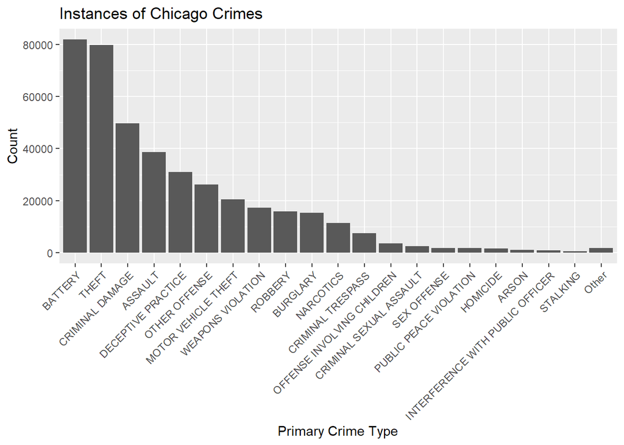

```r
cleaned_crime_data %>%
  mutate(fac_type=`Primary Type` %>% fct_infreq()) %>%
  mutate(fac_type=fct_lump(fac_type, n=20)) %>%
  ggplot(aes(x=fac_type)) +
  ggtitle("Instances of Chicago Crimes") +
  xlab("Primary Crime Type") +
  ylab("Count") +
  theme(axis.text.x=element_text(angle=45, hjust=1)) +
  geom_bar()
```

### NOAA Chicago Weather Dataset

There are a total of 46 unique features in the dataset.

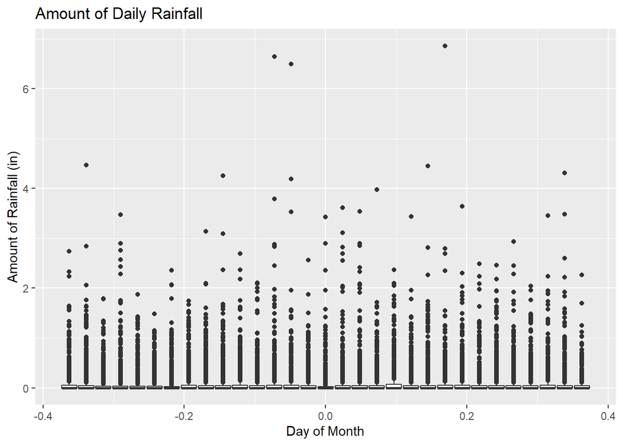

```r
ggplot(cleaned_weather_data, aes(group=day(Date), y=PRCP)) +
  ggtitle("Amount of Daily Rainfall") +
  xlab("Day of Month") +
  ylab("Amount of Rainfall (in)") +
  geom_boxplot()
```

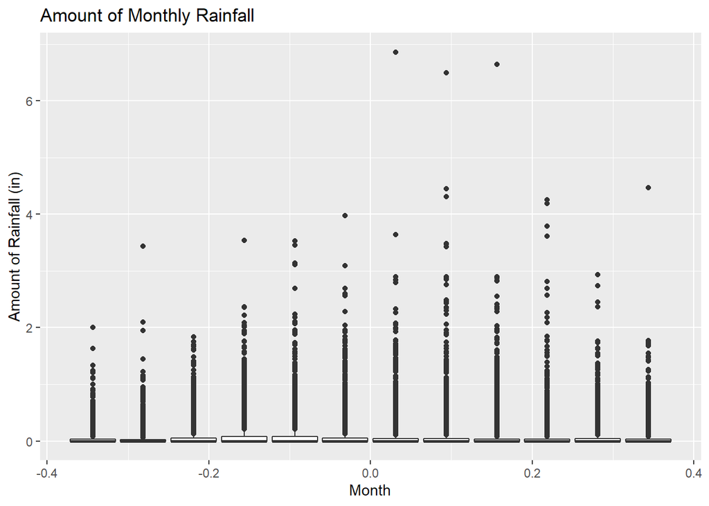

```r
ggplot(cleaned_weather_data, aes(group=month(Date), y=PRCP)) +
  ggtitle("Amount of Monthly Rainfall") +
  xlab("Month") +
  ylab("Amount of Rainfall (in)") +
  geom_boxplot()
```

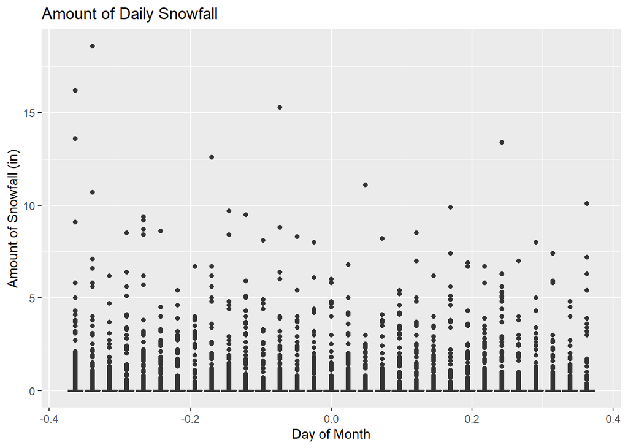

```r
ggplot(cleaned_weather_data, aes(group=day(Date), y=SNOW)) +
  ggtitle("Amount of Daily Snowfall") +
  xlab("Day of Month") +
  ylab("Amount of Snowfall (in)") +
  geom_boxplot()
```

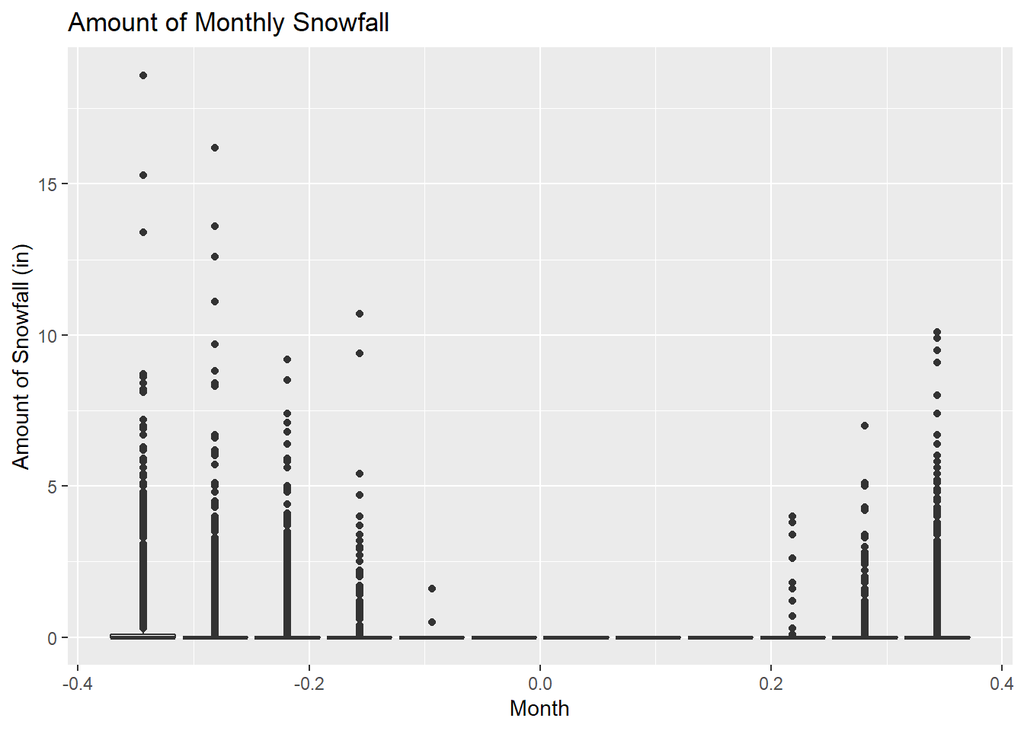

```r
ggplot(cleaned_weather_data, aes(group=month(Date), y=SNOW)) +
  ggtitle("Amount of Monthly Snowfall") +
  xlab("Month") +
  ylab("Amount of Snowfall (in)") +
  geom_boxplot()
```

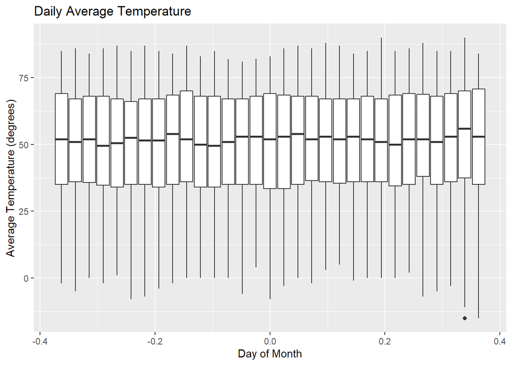

```r
ggplot(cleaned_weather_data, aes(group=day(Date), y=TAVG)) +
  ggtitle("Daily Average Temperature") +
  xlab("Day of Month") +
  ylab("Average Temperature (degrees)") +
  geom_boxplot()
```

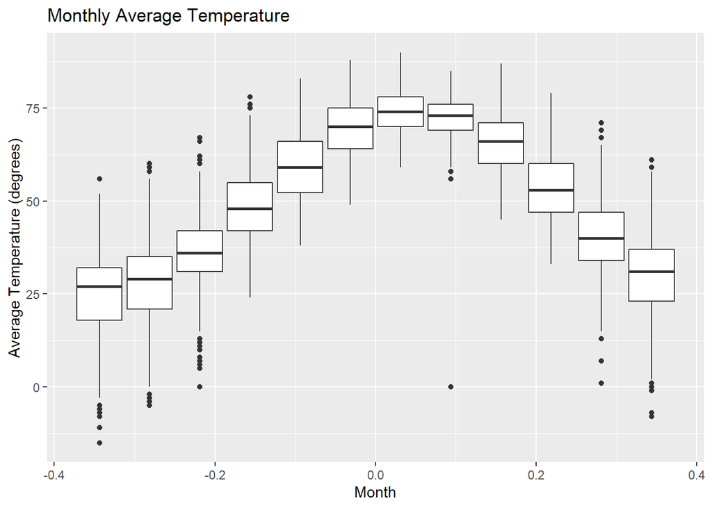

```r
ggplot(cleaned_weather_data, aes(group=month(Date), y=TAVG)) +
  ggtitle("Monthly Average Temperature") +
  xlab("Month") +
  ylab("Average Temperature (degrees)") +
  geom_boxplot()
```

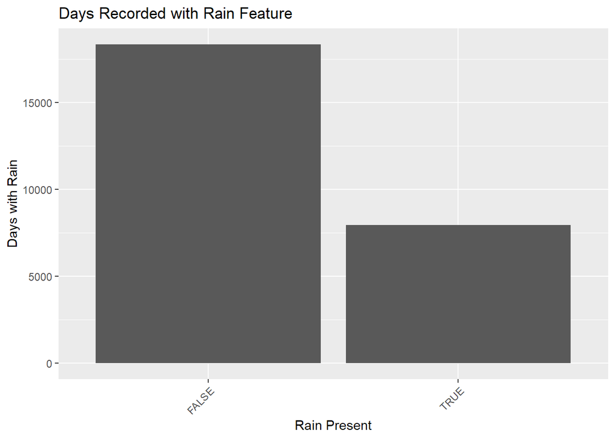

```r
cleaned_weather_data %>%
  ggplot(aes(x=Rain)) +
  ggtitle("Days Recorded with Rain Feature") +
  xlab("Rain Present") +
  ylab("Days with Rain") +
  theme(axis.text.x=element_text(angle=45, hjust=1)) +
  geom_bar()
```

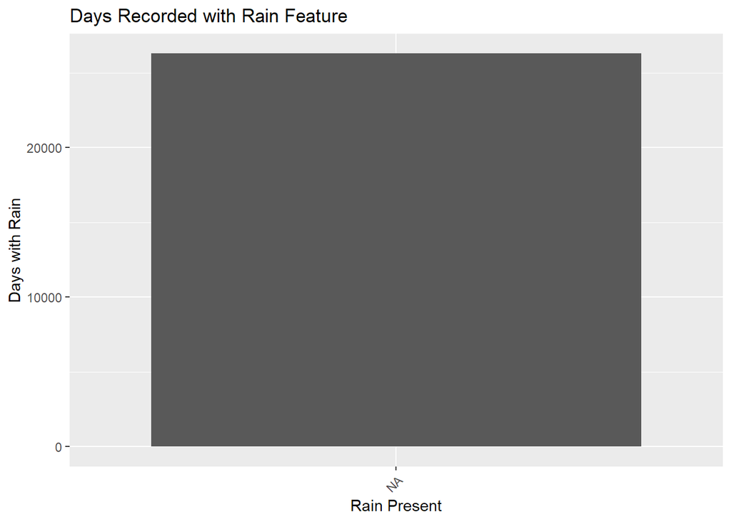

```r
cleaned_weather_data[cleaned_weather_data$Date > dmy("12/31/2019"),] %>%
  ggplot(aes(x=Rain)) +
  ggtitle("Days Recorded with Rain Feature") +
  xlab("Rain Present") +
  ylab("Days with Rain") +
  theme(axis.text.x=element_text(angle=45, hjust=1)) +
  geom_bar()
```

### Chicago Park Dataset

There are a total of 544 unique parks in the dataset.

There are a total of 66 unique facility types in the dataset.

There are a total of 3 unique facility locations in the dataset.

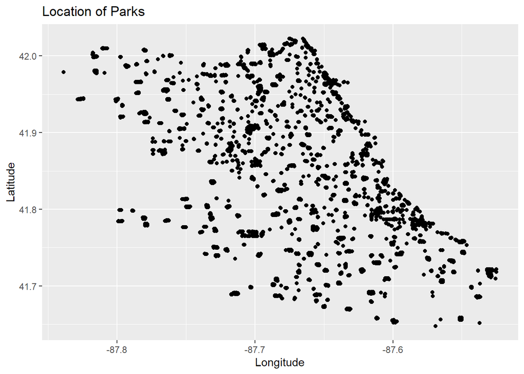

```r
ggplot(cleaned_park_data, aes(x=Longitude, y=Latitude)) +
  ggtitle("Location of Parks") +
  geom_point()
```

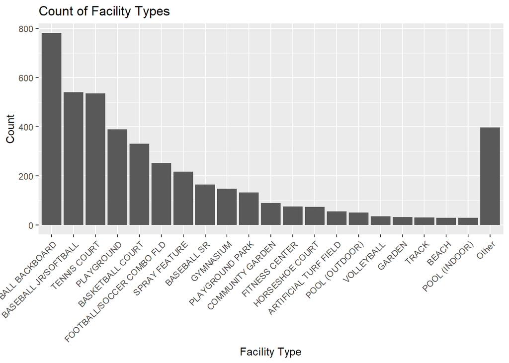

```r
cleaned_park_data %>%
  mutate(fac_type=FACILITY_N %>% fct_infreq()) %>%
  mutate(fac_type=fct_lump(fac_type, n=20)) %>%
  ggplot(aes(x=fac_type)) +
  ggtitle("Count of Facility Types") +
  xlab("Facility Type") +
  ylab("Count") +
  theme(axis.text.x=element_text(angle=45, hjust=1)) +
  geom_bar()
```

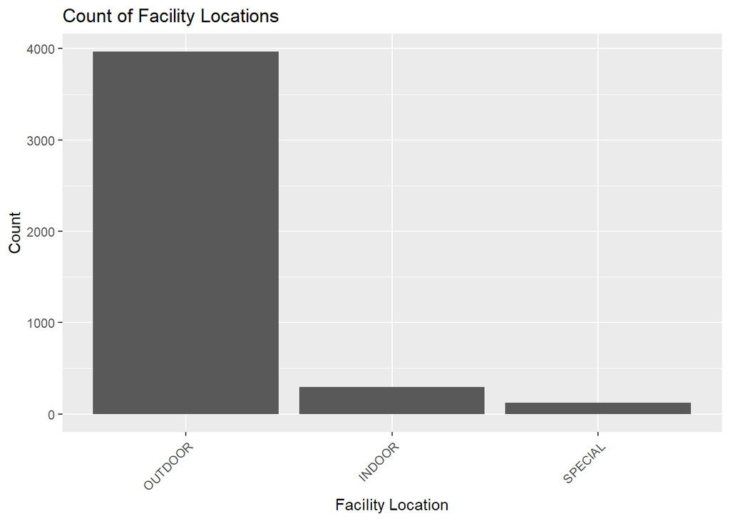

```r
cleaned_park_data %>%
  mutate(fac_type=FACILITY_T %>% fct_infreq()) %>%
  ggplot(aes(x=fac_type)) +
  ggtitle("Count of Facility Locations") +
  xlab("Facility Location") +
  ylab("Count") +
  theme(axis.text.x=element_text(angle=45, hjust=1)) +
  geom_bar()
```

### Chicago Library Dataset

There are a total of 81 unique libraries in the dataset.

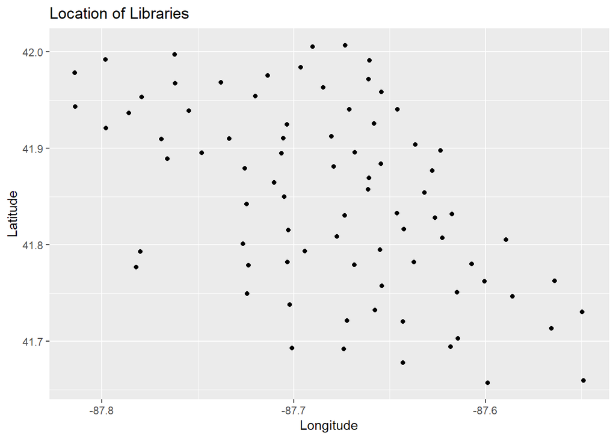

```r
ggplot(cleaned_library_data, aes(x=Longitude, y=Latitude)) +
  ggtitle("Location of Libraries") +
  geom_point()
```

### Chicago Public Art Dataset

There are a total of 185 unique pieces of art in the dataset.

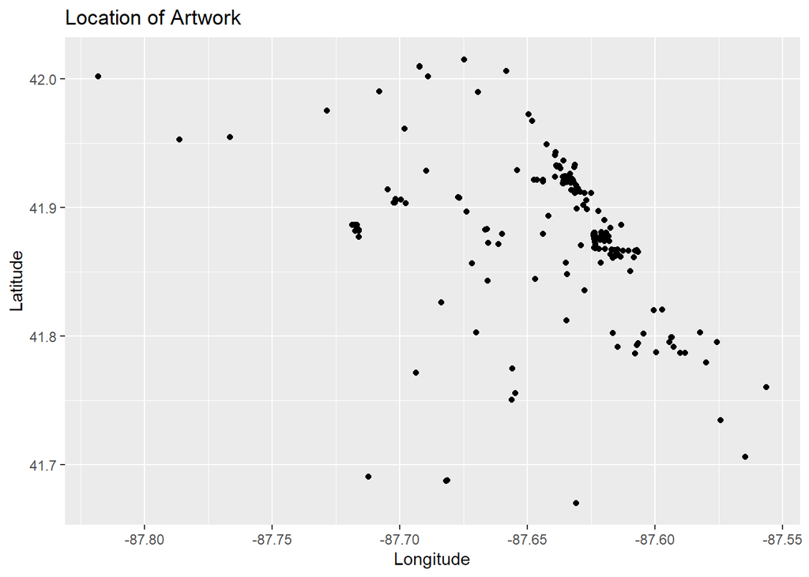

```r
scale <- function(x) sprintf("%.1f", x)

ggplot(cleaned_art_data, aes(x=Longitude, y=Latitude)) +
  ggtitle("Location of Artwork") +
  geom_point()
```

### Hypothesis 1 Testing

Hypothesis: The likelihood of an arrest can be calculated from the type of crime and weather features.

#### Visualization

We wanted to visualize some of the relationships between our variables of interest. Here we have the amount of precipitation that day (in inches) mapped with whether or not they resulted in an arrest.

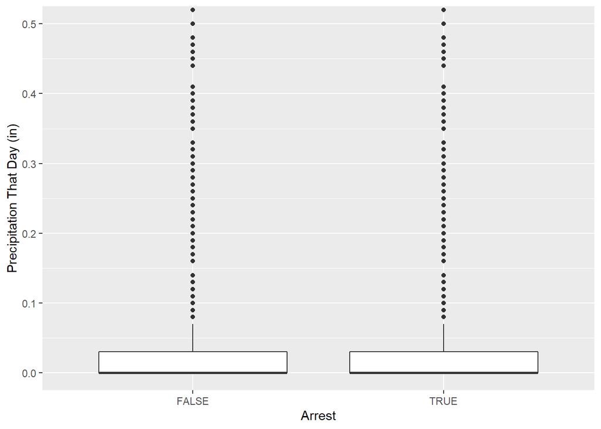

```r
ggplot(combined_data, aes(x=Arrest, y= PRCP)) +
  xlab("Arrest") +
  ylab("Precipitation That Day (in)") +
  geom_boxplot() +
  coord_cartesian(ylim =  c(0, 0.5))
```

Then we looked for any relationship between arrests and the amount of snow Chicago got that day (in inches).

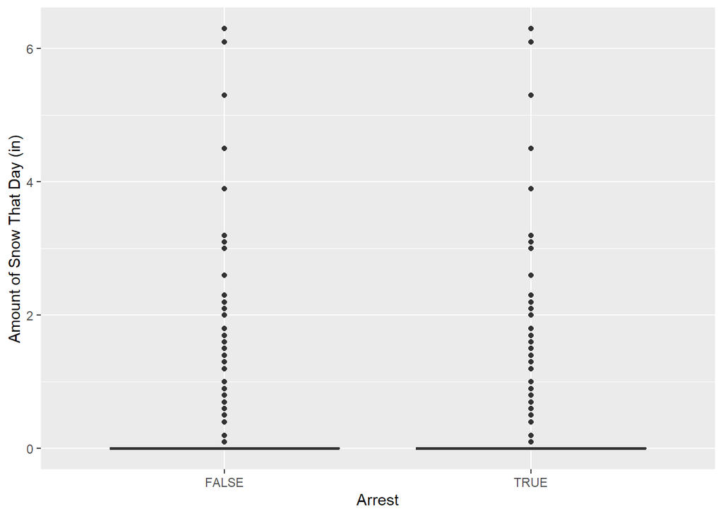

```r
ggplot(combined_data, aes(x=Arrest, y= SNOW)) +
  xlab("Arrest") +
  ylab("Amount of Snow That Day (in)") +
  geom_boxplot()
```

Then we looked for any relationship between arrests and the average temperature for the day.

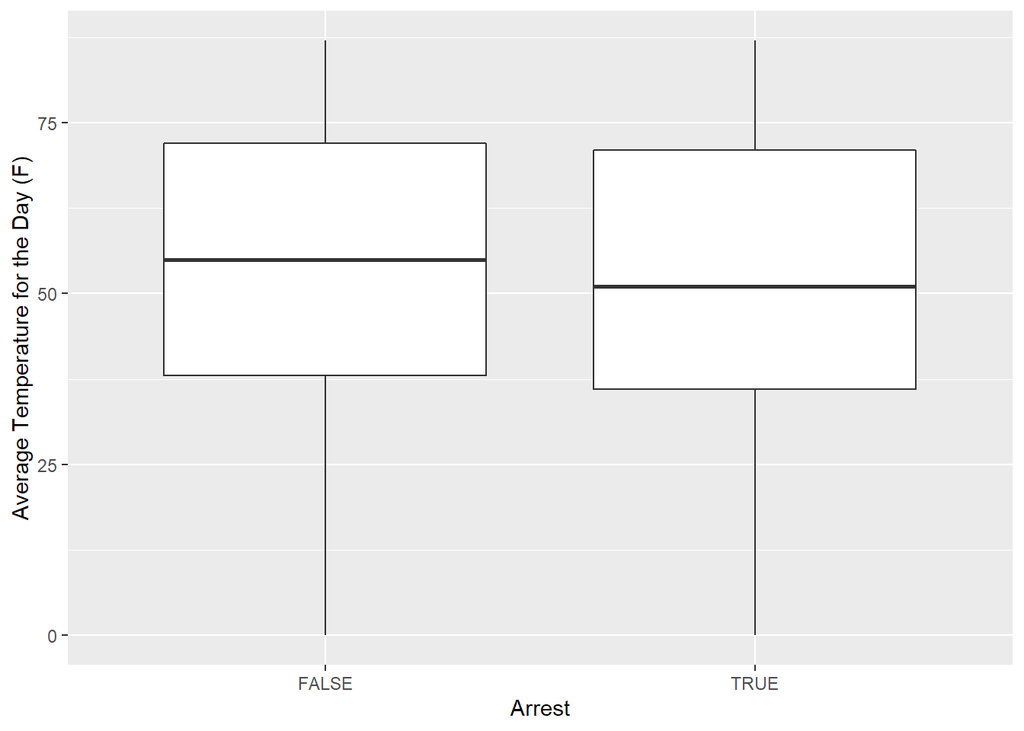

```r
ggplot(combined_data, aes(x=Arrest, y= TAVG)) +
  xlab("Arrest") +
  ylab("Average Temperature for the Day (F)") +
  geom_boxplot()
```

Then we looked for any relationship between arrests and the highest temperature of the day.

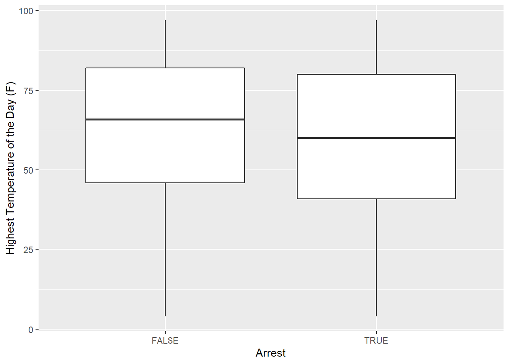

```r
ggplot(combined_data, aes(x=Arrest, y= TMAX)) +
  xlab("Arrest") +
  ylab("Highest Temperature of the Day (F)") +
  geom_boxplot()
```

Then we looked for any relationship between arrests and the lowest temperature of the day.

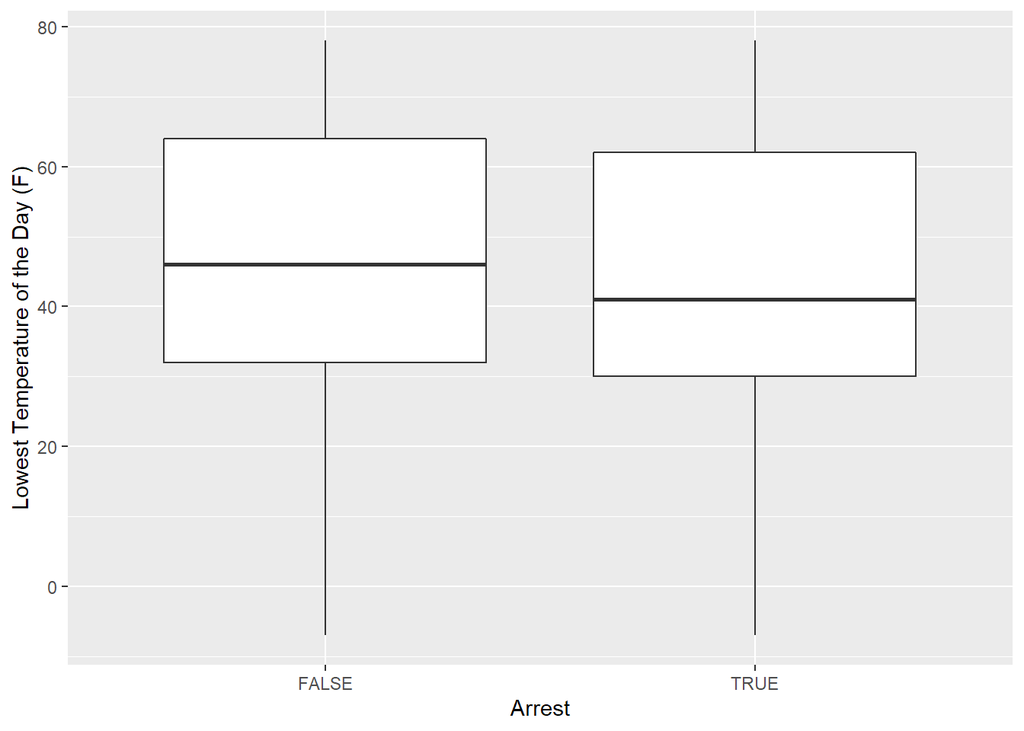

```r
ggplot(combined_data, aes(x=Arrest, y= TMIN)) +
  xlab("Arrest") +
  ylab("Lowest Temperature of the Day (F)") +
  geom_boxplot()
```

Then we looked for any relationship between the type of crime and the amount of precipitation.

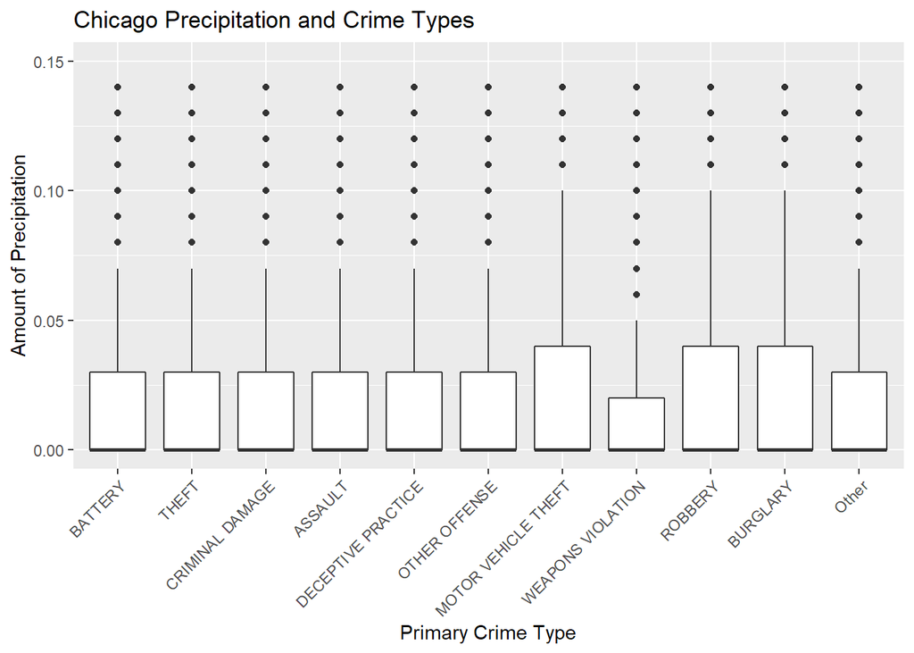

```r
combined_data %>% mutate(fac_type=`Primary Type` %>% fct_infreq()) %>%
  mutate(fac_type=fct_lump(fac_type, n=10)) %>%
  ggplot(aes(x=fac_type, y= PRCP)) +
  ggtitle("Chicago Precipitation and Crime Types") +
  xlab("Primary Crime Type") +
  ylab("Amount of Precipitation") +
  theme(axis.text.x=element_text(angle=45, hjust=1)) +
  geom_boxplot() +
  coord_cartesian(ylim =  c(0, 0.15))
```

Then we looked for any relationship between the type of crime and the average temperature for the day.

[figure not shown]

```r
combined_data %>% mutate(fac_type=`Primary Type` %>% fct_infreq()) %>%
  mutate(fac_type=fct_lump(fac_type, n=10)) %>%
  ggplot(aes(x=fac_type, y= TAVG)) +
  ggtitle("Chicago Precipitation and Crime Types") +
  xlab("Primary Crime Type") +
  ylab("Amount of Precipitation") +
  theme(axis.text.x=element_text(angle=45, hjust=1)) +
  geom_boxplot()
```

We also looked at the relationship between type of crime and whether it resulted in an arrest.

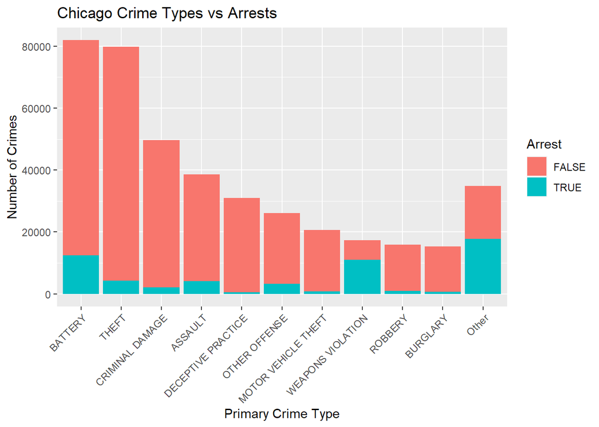

```r
combined_data %>% mutate(fac_type=`Primary Type` %>% fct_infreq()) %>%
  mutate(fac_type=fct_lump(fac_type, n=10)) %>%
  ggplot(aes(fac_type, ..count..)) +
  ggtitle("Chicago Crime Types vs Arrests") +
  xlab("Primary Crime Type") +
  ylab("Number of Crimes") +
  theme(axis.text.x=element_text(angle=45, hjust=1)) +
  geom_bar(aes(fill=Arrest))
```

And calculated the ratio of arrests to each specific crime.

```r
combined_data %>%
  count(`Primary Type`, Arrest, .drop=FALSE) %>%
  complete(`Primary Type`, Arrest) %>%
  group_by(`Primary Type`) %>%
  mutate(percent_arrested = n[Arrest == TRUE]/sum(n)) %>%
  filter(Arrest == FALSE) %>%
  select(-c(Arrest, n)) %>%
  arrange(desc(percent_arrested))
```

| Primary Type | percent_arrested |
| --- | --- |
| PROSTITUTION | 0.99189189 |
| NARCOTICS | 0.98740643 |
| CONCEALED CARRY LICENSE VIOLATION | 0.96865204 |
| GAMBLING | 0.94736842 |
| INTERFERENCE WITH PUBLIC OFFICER | 0.89256198 |
| OBSCENITY | 0.79381443 |
| WEAPONS VIOLATION | 0.63185138 |
| OTHER NARCOTIC VIOLATION | 0.62500000 |
| PUBLIC PEACE VIOLATION | 0.37130575 |
| CRIMINAL TRESPASS | 0.35711444 |

[output cut: 23 more lines]

#### Statistical Testing

We then did some statistical testing to see whether the variables we will use in our model are statistically significant to an arrest occurring using an alpha of 0.05.

```r
wilcox.test(PRCP~ Arrest,
            data = combined_data,
            exact = FALSE)
```

```
##
##  Wilcoxon rank sum test with continuity correction
##
## data:  PRCP by Arrest
## W = 1.0219e+10, p-value = 0.01191
## alternative hypothesis: true location shift is not equal to 0
```

```r
wilcox.test(SNOW~ Arrest,
            data = combined_data,
            exact = FALSE)
```

```
##
##  Wilcoxon rank sum test with continuity correction
##
## data:  SNOW by Arrest
## W = 9942325490, p-value < 2.2e-16
## alternative hypothesis: true location shift is not equal to 0
```

```r
wilcox.test(TAVG~ Arrest,
            data = combined_data,
            exact = FALSE)
```

```
##
##  Wilcoxon rank sum test with continuity correction
##
## data:  TAVG by Arrest
## W = 1.0928e+10, p-value < 2.2e-16
## alternative hypothesis: true location shift is not equal to 0
```

```r
wilcox.test(TMAX~ Arrest,
            data = combined_data,
            exact = FALSE)
```

```
##
##  Wilcoxon rank sum test with continuity correction
##
## data:  TMAX by Arrest
## W = 1.0881e+10, p-value < 2.2e-16
## alternative hypothesis: true location shift is not equal to 0
```

```r
wilcox.test(TMIN~ Arrest,
            data = combined_data,
            exact = FALSE)
```

```
##
##  Wilcoxon rank sum test with continuity correction
##
## data:  TMIN by Arrest
## W = 1.091e+10, p-value < 2.2e-16
## alternative hypothesis: true location shift is not equal to 0
```

```r
chisq.test(with(combined_data,table(Arrest, `Primary Type`)))
```

```
##
##  Pearson's Chi-squared test
##
## data:  with(combined_data, table(Arrest, `Primary Type`))
## X-squared = 134920, df = 32, p-value < 2.2e-16
```

#### Modeling and Prediction

Then we created a logistic regression model to predict arrests given just the primary type of crime.

```r
# Split data into training and testing datasets
set.seed(123)
training.samples <- sample(seq_len(nrow(combined_data)), size = floor(0.8 * nrow(combined_data)))
train.data  <- combined_data[training.samples, ]
test.data <- combined_data[-training.samples, ]
rm(training.samples)

# Fitting logistic regression model to predict arrests with just primary type
model <- glm(Arrest ~ `Primary Type`, data = train.data, family = binomial)

# Make predictions
probabilities <- model %>% predict(test.data, type = "response")
predicted.classes <- ifelse(probabilities > 0.5, "TRUE", "FALSE")
# Model accuracy
cat('Logistic Regression Model Accuracy w/ just primary type: ', round(mean(predicted.classes == test.data$Arrest, na.rm=TRUE),4) * 100, '%')
```

```
## Logistic Regression Model Accuracy w/ just primary type:  90.25 %
```

Then we created an additional logistic regression model to predict arrests given the amount of precipitation and type of crime.

```r
# Fitting logistic regression model to predict arrests with primary type of crime and precipitation amount
model <- glm(Arrest ~ `Primary Type` + PRCP, data = train.data, family = binomial)

# Make predictions
probabilities <- model %>% predict(test.data, type = "response")
predicted.classes <- ifelse(probabilities > 0.5, "TRUE", "FALSE")
# Model accuracy
cat('Logistic Regression Model Accuracy w/ added precipitation amount: ', round(mean(predicted.classes == test.data$Arrest, na.rm=TRUE),4) * 100, '%')
```

```
## Logistic Regression Model Accuracy w/ added precipitation amount:  90.23 %
```

We then created a third logistic regression model to predict arrests given the type of crime and the average, highest, and lowest temperatures for the day.

```r
# Fitting logistic regression model to predict arrests with primary type and average, max, and min temperature
model <- glm(Arrest ~ `Primary Type` + TAVG + TMAX + TMIN, data = train.data, family = binomial)

# Make predictions
probabilities <- model %>% predict(test.data, type = "response")
predicted.classes <- ifelse(probabilities > 0.5, "TRUE", "FALSE")
# Model accuracy
cat('Logistic Regression Model Accuracy w/ added temperature info: ', round(mean(predicted.classes == test.data$Arrest, na.rm=TRUE),4) * 100, '%')
```

```
## Logistic Regression Model Accuracy w/ added temperature info:  90.25 %
```

Summary output of the best performing model.

```r
# Summarize the best model
summary(model)
```

```
##
## Call:
## glm(formula = Arrest ~ `Primary Type` + TAVG + TMAX + TMIN, family = binomial,
##     data = train.data)
##
## Deviance Residuals:
##     Min       1Q   Median       3Q      Max
## -3.0572  -0.5004  -0.3266  -0.2709   2.9212
##
## Coefficients:
##                                                   Estimate Std. Error z value
## (Intercept)                                     -2.141e+00  1.315e-01 -16.285
## `Primary Type`ASSAULT                            3.904e-01  1.312e-01   2.976
## `Primary Type`BATTERY                            8.200e-01  1.303e-01   6.293
## `Primary Type`BURGLARY                          -4.974e-01  1.368e-01  -3.635
## `Primary Type`CONCEALED CARRY LICENSE VIOLATION  6.000e+00  3.820e-01  15.707
## `Primary Type`CRIM SEXUAL ASSAULT               -8.992e-01  7.323e-01  -1.228
## `Primary Type`CRIMINAL DAMAGE                   -5.909e-01  1.322e-01  -4.468
## `Primary Type`CRIMINAL SEXUAL ASSAULT           -5.917e-01  1.712e-01  -3.457
## `Primary Type`CRIMINAL TRESPASS                  1.944e+00  1.326e-01  14.659
## `Primary Type`DECEPTIVE PRACTICE                -1.495e+00  1.384e-01 -10.801
## `Primary Type`GAMBLING                           5.280e+00  7.428e-01   7.108
## `Primary Type`HOMICIDE                           1.769e+00  1.433e-01  12.342
## `Primary Type`HUMAN TRAFFICKING                 -1.107e+01  1.337e+02  -0.083
## `Primary Type`INTERFERENCE WITH PUBLIC OFFICER   4.696e+00  1.776e-01  26.446
## `Primary Type`INTIMIDATION                      -7.804e-01  3.826e-01  -2.039
## `Primary Type`KIDNAPPING                        -2.765e-01  3.507e-01  -0.788
## `Primary Type`LIQUOR LAW VIOLATION               1.612e+01  3.361e+01   0.480
## `Primary Type`MOTOR VEHICLE THEFT               -6.557e-01  1.358e-01  -4.828
## `Primary Type`NARCOTICS                          6.813e+00  1.591e-01  42.827
## `Primary Type`NON-CRIMINAL                       1.055e+00  1.127e+00   0.936
## `Primary Type`OBSCENITY                          3.891e+00  3.090e-01  12.593
## `Primary Type`OFFENSE INVOLVING CHILDREN         1.045e-01  1.461e-01   0.715
## `Primary Type`OTHER NARCOTIC VIOLATION           2.976e+00  7.425e-01   4.008
## `Primary Type`OTHER OFFENSE                      5.659e-01  1.315e-01   4.302
## `Primary Type`PROSTITUTION                       7.111e+00  5.948e-01  11.954
## `Primary Type`PUBLIC INDECENCY                   1.611e+01  1.691e+02   0.095
## `Primary Type`PUBLIC PEACE VIOLATION             2.024e+00  1.404e-01  14.417
## `Primary Type`RITUALISM                         -1.116e+01  5.354e+02  -0.021
## `Primary Type`ROBBERY                           -2.210e-01  1.351e-01  -1.635
```

[output cut: 40 more lines]

```
## `Primary Type`WEAPONS VIOLATION                  < 2e-16 ***
## TAVG                                            0.898823
## TMAX                                            0.001770 **
## TMIN                                            0.367534
## ---
## Signif. codes:  0 '***' 0.001 '**' 0.01 '*' 0.05 '.' 0.1 ' ' 1
##
## (Dispersion parameter for binomial family taken to be 1)
##
##     Null deviance: 266749  on 328521  degrees of freedom
## Residual deviance: 188213  on 328486  degrees of freedom
##   (429 observations deleted due to missingness)
## AIC: 188285
##
## Number of Fisher Scoring iterations: 12
```

### Hypothesis 2 Testing

Hypothesis: The likelihood of an arrest can be calculated from the type of crime and the crime’s location in relation of libraries, parks, and public art.

#### Visualization

We wanted to visualize some of the relationships between our variables of interest. Here we have the locations of the crimes mapped with whether or not they resulted in an arrest.

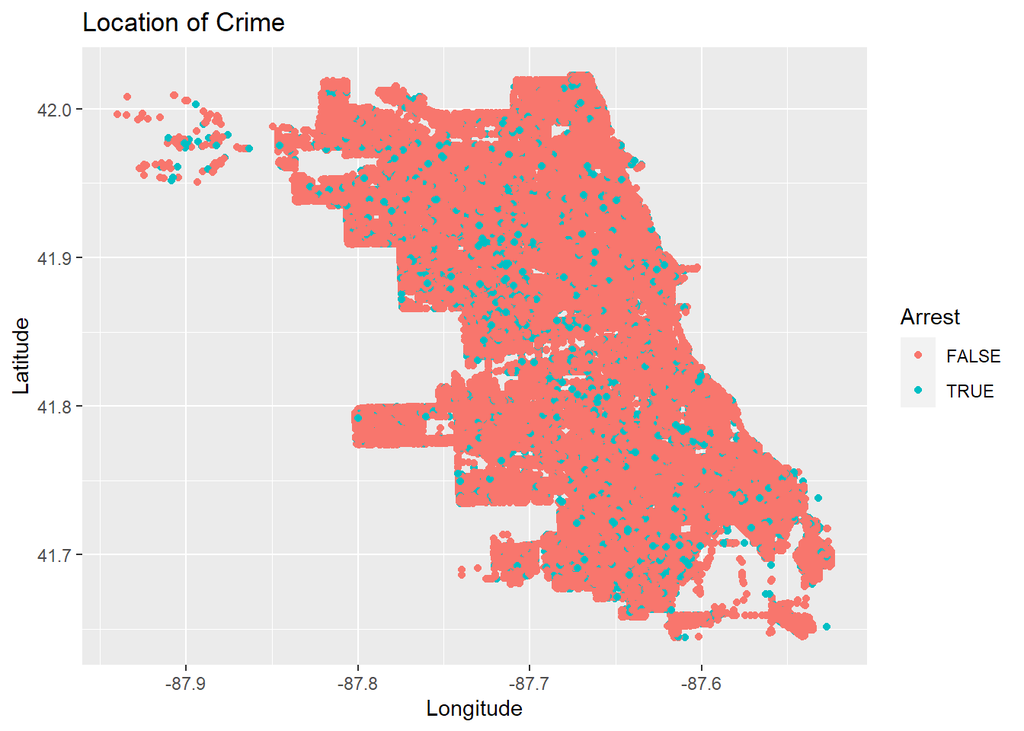

```r
ggplot(combined_data, aes(x=Longitude, y=Latitude, col=Arrest)) +
  ggtitle("Location of Crime") +
  geom_point()
```

Here we are looking for any relationship between arrests and the distance to art.

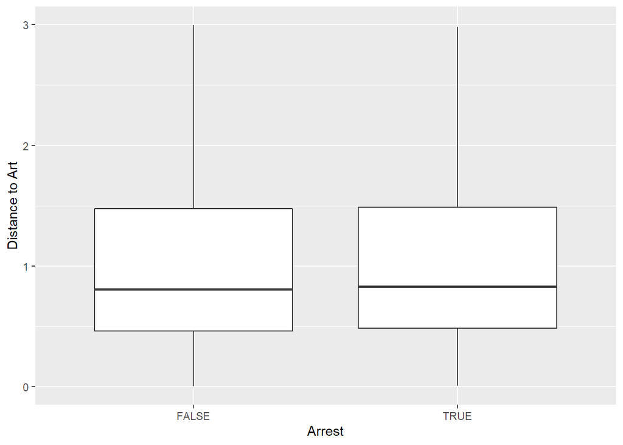

```r
ggplot(combined_data, aes(x=Arrest, y= art_dist)) +
  xlab("Arrest") +
  ylab("Distance to Art") +
  geom_boxplot(outlier.shape = NA) +
  coord_cartesian(ylim =  c(0, 3))
```

Here we are reviewed the relationship between arrests and the distance to the parks.

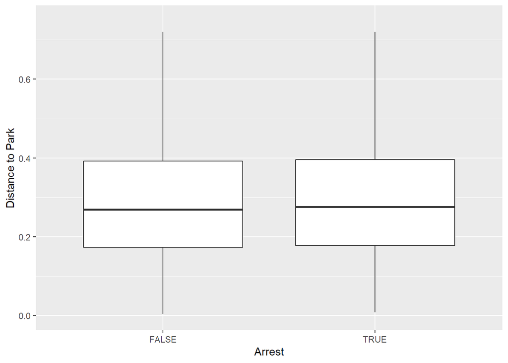

```r
ggplot(combined_data, aes(x=Arrest, y= park_dist)) +
  xlab("Arrest") +
  ylab("Distance to Park") +
  geom_boxplot(outlier.shape = NA) +
  coord_cartesian(ylim =  c(0, 0.75))
```

Then we looked for any difference between the type of crime and the distance to the public art.

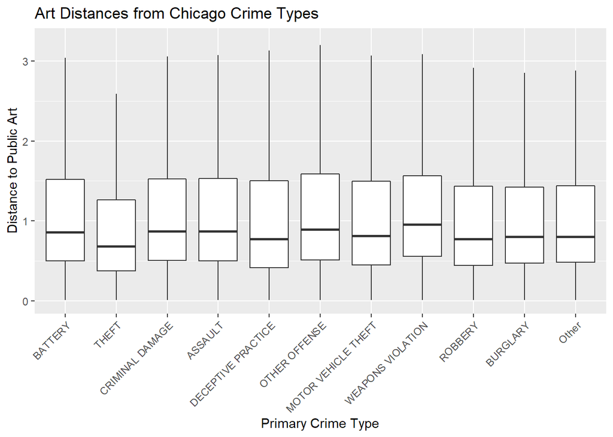

```r
combined_data %>% mutate(fac_type=`Primary Type` %>% fct_infreq()) %>%
  mutate(fac_type=fct_lump(fac_type, n=10)) %>%
  ggplot(aes(x=fac_type, y= art_dist)) +
  ggtitle("Art Distances from Chicago Crime Types") +
  xlab("Primary Crime Type") +
  ylab("Distance to Public Art") +
  theme(axis.text.x=element_text(angle=45, hjust=1)) +
  geom_boxplot(outlier.shape = NA) +
  coord_cartesian(ylim =  c(0, 3.25))
```

Then we looked for any difference between the type of crime and the distance to the parks.

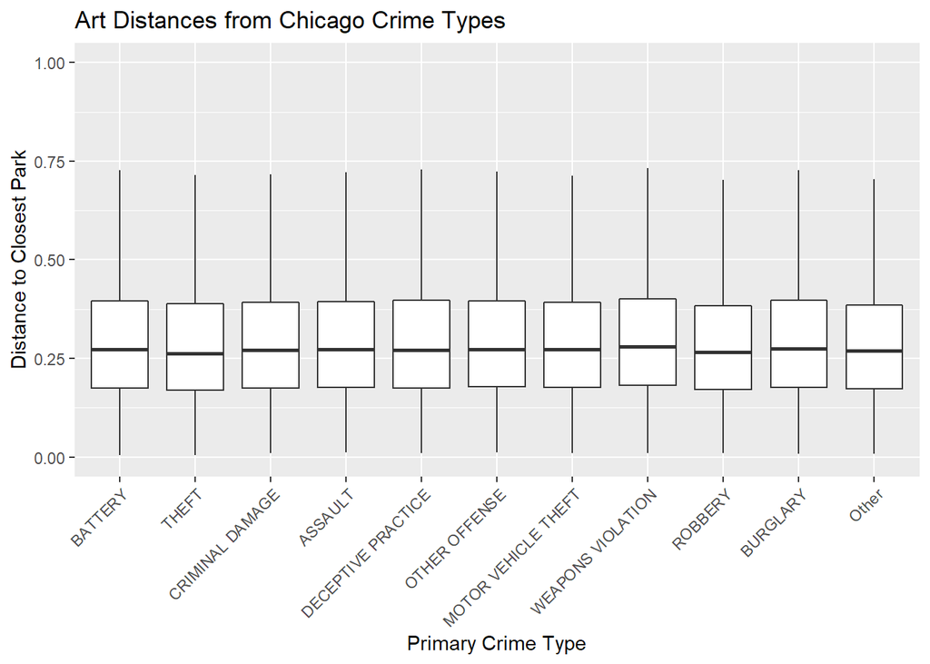

```r
combined_data %>% mutate(fac_type=`Primary Type` %>% fct_infreq()) %>%
  mutate(fac_type=fct_lump(fac_type, n=10)) %>%
  ggplot(aes(x=fac_type, y= park_dist)) +
  ggtitle("Art Distances from Chicago Crime Types") +
  xlab("Primary Crime Type") +
  ylab("Distance to Closest Park") +
  theme(axis.text.x=element_text(angle=45, hjust=1)) +
  geom_boxplot(outlier.shape = NA) +
  coord_cartesian(ylim =  c(0, 1))
```

We also looked at the relationship between type of crime and whether it resulted in an arrest.

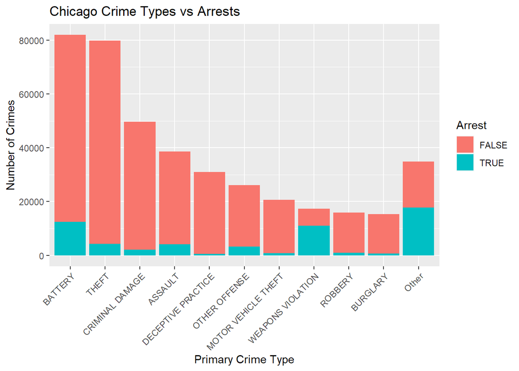

```r
combined_data %>% mutate(fac_type=`Primary Type` %>% fct_infreq()) %>%
  mutate(fac_type=fct_lump(fac_type, n=10)) %>%
  ggplot(aes(fac_type, ..count..)) +
  ggtitle("Chicago Crime Types vs Arrests") +
  xlab("Primary Crime Type") +
  ylab("Number of Crimes") +
  theme(axis.text.x=element_text(angle=45, hjust=1)) +
  geom_bar(aes(fill=Arrest))
```

And calculated the ratio of arrests to each specific crime.

```r
combined_data %>%
  count(`Primary Type`, Arrest, .drop=FALSE) %>%
  complete(`Primary Type`, Arrest) %>%
  group_by(`Primary Type`) %>%
  mutate(percent_arrested = n[Arrest == TRUE]/sum(n)) %>%
  filter(Arrest == FALSE) %>%
  select(-c(Arrest, n)) %>%
  arrange(desc(percent_arrested))
```

| Primary Type | percent_arrested |
| --- | --- |
| PROSTITUTION | 0.99189189 |
| NARCOTICS | 0.98740643 |
| CONCEALED CARRY LICENSE VIOLATION | 0.96865204 |
| GAMBLING | 0.94736842 |
| INTERFERENCE WITH PUBLIC OFFICER | 0.89256198 |
| OBSCENITY | 0.79381443 |
| WEAPONS VIOLATION | 0.63185138 |
| OTHER NARCOTIC VIOLATION | 0.62500000 |
| PUBLIC PEACE VIOLATION | 0.37130575 |
| CRIMINAL TRESPASS | 0.35711444 |

[output cut: 23 more lines]

#### Statistical Testing

We then did some statistical testing to see whether the variables we will use in our model are statistically significant to an arrest occurring using an alpha of 0.05.

```r
wilcox.test(Latitude~ Arrest,
            data = combined_data,
            exact = FALSE)
```

```
##
##  Wilcoxon rank sum test with continuity correction
##
## data:  Latitude by Arrest
## W = 1.0468e+10, p-value < 2.2e-16
## alternative hypothesis: true location shift is not equal to 0
```

```r
wilcox.test(Longitude~ Arrest,
            data = combined_data,
            exact = FALSE)
```

```
##
##  Wilcoxon rank sum test with continuity correction
##
## data:  Longitude by Arrest
## W = 1.086e+10, p-value < 2.2e-16
## alternative hypothesis: true location shift is not equal to 0
```

```r
wilcox.test(park_dist~ Arrest,
            data = combined_data,
            exact = FALSE)
```

```
##
##  Wilcoxon rank sum test with continuity correction
##
## data:  park_dist by Arrest
## W = 1.0032e+10, p-value = 4.342e-13
## alternative hypothesis: true location shift is not equal to 0
```

```r
wilcox.test(library_dist~ Arrest,
            data = combined_data,
            exact = FALSE)
```

```
##
##  Wilcoxon rank sum test with continuity correction
##
## data:  library_dist by Arrest
## W = 1.0336e+10, p-value = 2.012e-05
## alternative hypothesis: true location shift is not equal to 0
```

```r
wilcox.test(art_dist~ Arrest,
            data = combined_data,
            exact = FALSE)
```

```
##
##  Wilcoxon rank sum test with continuity correction
##
## data:  art_dist by Arrest
## W = 1.0059e+10, p-value = 5.106e-10
## alternative hypothesis: true location shift is not equal to 0
```

```r
chisq.test(with(combined_data,table(Arrest, `Primary Type`)))
```

```
##
##  Pearson's Chi-squared test
##
## data:  with(combined_data, table(Arrest, `Primary Type`))
## X-squared = 134920, df = 32, p-value < 2.2e-16
```

#### Modeling and Prediction

Then we created a logistic regression model to predict arrests given the crime location.

```r
# Split data into training and testing datasets
set.seed(123)
training.samples <- sample(seq_len(nrow(combined_data)), size = floor(0.8 * nrow(combined_data)))
train.data  <- combined_data[training.samples, ]
test.data <- combined_data[-training.samples, ]
rm(training.samples)

# Fitting logistic regression model to predict arrests with just location
model <- glm( Arrest ~ Latitude + Longitude , data = train.data, family = binomial)

# Make predictions
probabilities <- model %>% predict(test.data, type = "response")
predicted.classes <- ifelse(probabilities > 0.5, "TRUE", "FALSE")
# Model accuracy
cat('Logistic Regression Model Accuracy w/ just crime location: ', round(mean(predicted.classes == test.data$Arrest),4) * 100, '%')
```

```
## Logistic Regression Model Accuracy w/ just crime location:  85.86 %
```

Then we created an additional logistic regression model to predict arrests given the location and type of crime.

```r
# Fitting logistic regression model to predict arrests with location and type of crime
model <- glm( Arrest ~ `Primary Type` + Latitude + Longitude, data = train.data, family = binomial)

# Make predictions
probabilities <- model %>% predict(test.data, type = "response")
predicted.classes <- ifelse(probabilities > 0.5, "TRUE", "FALSE")
# Model accuracy
cat('Logistic Regression Model Accuracy w/o added distances: ', round(mean(predicted.classes == test.data$Arrest),4) * 100, '%')
```

```
## Logistic Regression Model Accuracy w/o added distances:  90.25 %
```

We then created a third logistic regression model to predict arrests given the type of crime and the distances to the nearest library, park, and public art.

```r
# Fitting logistic regression model to predict arrests without using distances to parks, art, and libraries
model <- glm( Arrest ~ `Primary Type` + park_dist + library_dist + art_dist, data = train.data, family = binomial)

# Make predictions
probabilities <- model %>% predict(test.data, type = "response")
predicted.classes <- ifelse(probabilities > 0.5, "TRUE", "FALSE")
# Model accuracy
cat('Logistic Regression Model Accuracy w/ added distances: ', round(mean(predicted.classes == test.data$Arrest),4) * 100, '%')
```

```
## Logistic Regression Model Accuracy w/ added distances:  90.28 %
```

Summary output of the best performing model.

```r
# Summarize the best model
summary(model)
```

```
##
## Call:
## glm(formula = Arrest ~ `Primary Type` + park_dist + library_dist +
##     art_dist, family = binomial, data = train.data)
##
## Deviance Residuals:
##     Min       1Q   Median       3Q      Max
## -3.0733  -0.4985  -0.3286  -0.2795   2.9090
##
## Coefficients:
##                                                   Estimate Std. Error z value
## (Intercept)                                      -2.575599   0.130263 -19.772
## `Primary Type`ASSAULT                             0.398268   0.131133   3.037
## `Primary Type`BATTERY                             0.828067   0.130258   6.357
## `Primary Type`BURGLARY                           -0.490052   0.136802  -3.582
## `Primary Type`CONCEALED CARRY LICENSE VIOLATION   5.873349   0.382370  15.360
## `Primary Type`CRIM SEXUAL ASSAULT                -0.717052   0.732257  -0.979
## `Primary Type`CRIMINAL DAMAGE                    -0.580297   0.132195  -4.390
## `Primary Type`CRIMINAL SEXUAL ASSAULT            -0.580856   0.171116  -3.395
## `Primary Type`CRIMINAL TRESPASS                   1.941088   0.132554  14.644
## `Primary Type`DECEPTIVE PRACTICE                 -1.452116   0.138304 -10.499
## `Primary Type`GAMBLING                            5.243283   0.742598   7.061
## `Primary Type`HOMICIDE                            1.759112   0.143220  12.283
## `Primary Type`HUMAN TRAFFICKING                 -11.026742 133.772834  -0.082
## `Primary Type`INTERFERENCE WITH PUBLIC OFFICER    4.728711   0.176983  26.718
## `Primary Type`INTIMIDATION                       -0.779980   0.382579  -2.039
## `Primary Type`KIDNAPPING                         -0.247756   0.350645  -0.707
## `Primary Type`LIQUOR LAW VIOLATION               16.106733  33.580390   0.480
## `Primary Type`MOTOR VEHICLE THEFT                -0.641780   0.135766  -4.727
## `Primary Type`NARCOTICS                           6.858113   0.159047  43.120
## `Primary Type`NON-CRIMINAL                        1.223224   1.125676   1.087
## `Primary Type`OBSCENITY                           3.910465   0.308744  12.666
## `Primary Type`OFFENSE INVOLVING CHILDREN          0.140796   0.146059   0.964
## `Primary Type`OTHER NARCOTIC VIOLATION            3.049427   0.742290   4.108
## `Primary Type`OTHER OFFENSE                       0.587137   0.131481   4.466
## `Primary Type`PROSTITUTION                        7.094049   0.594774  11.927
## `Primary Type`PUBLIC INDECENCY                   16.117359 169.245202   0.095
## `Primary Type`PUBLIC PEACE VIOLATION              1.998140   0.140375  14.234
## `Primary Type`RITUALISM                         -10.976542 535.411184  -0.021
## `Primary Type`ROBBERY                            -0.202245   0.135086  -1.497
```

[output cut: 39 more lines]

```
## `Primary Type`THEFT                             0.012180 *
## `Primary Type`WEAPONS VIOLATION                  < 2e-16 ***
## park_dist                                        < 2e-16 ***
## library_dist                                    6.53e-07 ***
## art_dist                                        1.04e-10 ***
## ---
## Signif. codes:  0 '***' 0.001 '**' 0.01 '*' 0.05 '.' 0.1 ' ' 1
##
## (Dispersion parameter for binomial family taken to be 1)
##
##     Null deviance: 267118  on 328950  degrees of freedom
## Residual deviance: 188669  on 328915  degrees of freedom
## AIC: 188741
##
## Number of Fisher Scoring iterations: 12
```

## Hypothesis 3 Testing

Days with inclement weather will have different amounts of the most common crime (Battery and Theft) than days without inclement weather

```r
crime_mann_whitney_test <- function(data, weather_condition) {
  weather_count <- data[weather_condition,] %>%
    group_by(date(DateTime), `Primary Type`) %>%
    count(`Primary Type`)

  non_weather_count <- data[!weather_condition,] %>%
    group_by(date(DateTime), `Primary Type`) %>%
    count(`Primary Type`)

  cat("Total number of", nrow(weather_count), "weather entries.\n")
  cat("Total number of", nrow(non_weather_count), "non-weather entries.\n")

  df = tibble(`Test` = c("Mann Whitney U P-Value"))

  for (type in unique(data$`Primary Type`)) {
    weather_occurrences <- weather_count[weather_count$`Primary Type` == type,]
    non_weather_occurrences <- non_weather_count[non_weather_count$`Primary Type` == type,]

    if (nrow(weather_occurrences) > 5 && nrow(non_weather_occurrences) > 5) {
      stat_result <- wilcox.test(weather_occurrences$n, non_weather_occurrences$n, exact=FALSE)
      df <- df %>% add_column(!!type := stat_result["p.value"][[1]])
    } else {
      df <- df %>% add_column(!!type := -1)
    }
  }

  return(df)
}
```

### Testing days with rain

```r
rain_p_values <- crime_mann_whitney_test(combined_data, (combined_data$PRCP > 0.0))
```

```
## Total number of 4737 weather entries.
## Total number of 9920 non-weather entries.
```

```r
rain_p_values
```

| Test | THEFT | MOTOR VEHICLE THEFT | ASSAULT | DECEPTIVE PRACTICE | NARCOTICS | ROBBERY | BATTERY | OTHER OFFENSE | BURGLARY | INTERFERENCE WITH PUBLIC OFFICER | SEX OFFENSE | WEAPONS VIOLATION | OFFENSE INVOLVING CHILDREN | CRIMINAL DAMAGE | STALKING | PUBLIC PEACE VIOLATION | ARSON | KIDNAPPING | CRIMINAL TRESPASS | INTIMIDATION | CRIMINAL SEXUAL ASSAULT | CONCEALED CARRY LICENSE VIOLATION | HOMICIDE | LIQUOR LAW VIOLATION | GAMBLING | OBSCENITY | PROSTITUTION | PUBLIC INDECENCY | HUMAN TRAFFICKING | … |
| --- | --- | --- | --- | --- | --- | --- | --- | --- | --- | --- | --- | --- | --- | --- | --- | --- | --- | --- | --- | --- | --- | --- | --- | --- | --- | --- | --- | --- | --- | --- |
| Mann Whitney U P-Value | 0.001786585 | 0.2954444 | 0.03004467 | 0.03280721 | 0.4572575 | 0.8183094 | 0.006292532 | 0.06580508 | 0.2549562 | 0.4874546 | 0.9217298 | 1.185892e-07 | 0.1594958 | 0.03196211 | 0.04147328 | 0.4844657 | 0.7159237 | 0.8556457 | 0.7465602 | 0.6897116 | 0.4355916 | 0.9661363 | 0.2933196 | 0.08022864 | 0.3516815 | 0.6115846 | 0.9591137 | -1 | NaN | … |

These results show that some types of crimes occur statistically different amounts on days with no rain, versus rain being present. With a p-value of 0.05, we can see that the most common crimes in Chicago, `battery` and `theft` occur in different amounts on days with rain versus days without rain. This allows us to reject the null hypothesis for both battery and theft, and accept the alternate hypothesis.

### Testing days with snow

```r
snow_p_values <- crime_mann_whitney_test(combined_data, (combined_data$SNOW > 0.0))
```

```
## Total number of 976 weather entries.
## Total number of 13626 non-weather entries.
```

```r
snow_p_values
```

| Test | THEFT | MOTOR VEHICLE THEFT | ASSAULT | DECEPTIVE PRACTICE | NARCOTICS | ROBBERY | BATTERY | OTHER OFFENSE | BURGLARY | INTERFERENCE WITH PUBLIC OFFICER | SEX OFFENSE | WEAPONS VIOLATION | OFFENSE INVOLVING CHILDREN | CRIMINAL DAMAGE | STALKING | PUBLIC PEACE VIOLATION | ARSON | KIDNAPPING | CRIMINAL TRESPASS | INTIMIDATION | CRIMINAL SEXUAL ASSAULT | CONCEALED CARRY LICENSE VIOLATION | HOMICIDE | LIQUOR LAW VIOLATION | GAMBLING | OBSCENITY | PROSTITUTION | PUBLIC INDECENCY | HUMAN TRAFFICKING | … |
| --- | --- | --- | --- | --- | --- | --- | --- | --- | --- | --- | --- | --- | --- | --- | --- | --- | --- | --- | --- | --- | --- | --- | --- | --- | --- | --- | --- | --- | --- | --- |
| Mann Whitney U P-Value | 2.268443e-05 | 2.697802e-06 | 9.887751e-10 | 0.002862635 | 0.001312979 | 0.3387235 | 3.597992e-09 | 0.3108324 | 0.0009629697 | 0.3408803 | 0.6057322 | 1.096105e-14 | 0.898392 | 2.619162e-12 | 0.08468789 | 0.5919378 | 0.1920732 | 0.5778791 | 0.9624042 | 0.6334944 | 0.01627648 | 0.5048517 | 2.551363e-05 | 0.930674 | -1 | 0.4805018 | 0.08723207 | -1 | -1 | … |

### Testing days with thunder

```r
thunder_p_values <- crime_mann_whitney_test(combined_data, (combined_data$Thunder == TRUE))
```

```
## Total number of 1768 weather entries.
## Total number of 12949 non-weather entries.
```

```r
thunder_p_values
```

| Test | THEFT | MOTOR VEHICLE THEFT | ASSAULT | DECEPTIVE PRACTICE | NARCOTICS | ROBBERY | BATTERY | OTHER OFFENSE | BURGLARY | INTERFERENCE WITH PUBLIC OFFICER | SEX OFFENSE | WEAPONS VIOLATION | OFFENSE INVOLVING CHILDREN | CRIMINAL DAMAGE | STALKING | PUBLIC PEACE VIOLATION | ARSON | KIDNAPPING | CRIMINAL TRESPASS | INTIMIDATION | CRIMINAL SEXUAL ASSAULT | CONCEALED CARRY LICENSE VIOLATION | HOMICIDE | LIQUOR LAW VIOLATION | GAMBLING | OBSCENITY | PROSTITUTION | PUBLIC INDECENCY | HUMAN TRAFFICKING | … |
| --- | --- | --- | --- | --- | --- | --- | --- | --- | --- | --- | --- | --- | --- | --- | --- | --- | --- | --- | --- | --- | --- | --- | --- | --- | --- | --- | --- | --- | --- | --- |
| Mann Whitney U P-Value | 0.3369981 | 0.1759389 | 0.000682422 | 0.002731579 | 0.005754943 | 0.2581423 | 0.004116137 | 0.7928162 | 0.212896 | 0.4990785 | 0.91404 | 0.7556936 | 0.9236452 | 2.247364e-05 | 0.1263498 | 0.9438465 | 0.1706031 | 0.1493109 | 0.8456448 | 0.2731017 | 0.2770218 | 0.8069646 | 0.2178469 | 0.08337315 | -1 | 1 | 0.005930868 | -1 | -1 | … |

These results show that some types of crimes occur statistically different amounts on days with no thunder, versus thunder being present. With this test, we are assuming Thunder implies more severe rain than above. With a p-value of 0.05, we can see that the most common crimes in Chicago, `battery` and `theft` don’t necessarily occur differently. `battery` occurs in a different quantity when thunder is present, whereas `theft` does not. This allows us to reject the null hypothesis for battery, but forces us to accept it for theft, and accept the alternate hypothesis.

### Testing a Linear Regression model

With our alternate hypothesis being accepted in most cases, we are now interested in moving to modelling. While the big difference is between there *being weather* and *not being weather*, we are curious about whether or not we can predict crime rates with the type of weather, or the amount of precipitation/snow.

### Testing Linear Regression Models

In the first section, we want to see if we can predict the amount of crimes per day with a linear regression between the snowfall or the precipitation versus the battery and theft crimes.

```r
snow_battery_model = lm(n ~ SNOW, data = battery_data)
summary(snow_battery_model)
```

```
##
## Call:
## lm(formula = n ~ SNOW, data = battery_data)
##
## Residuals:
##    Min     1Q Median     3Q    Max
## -59.23 -17.23  -2.23  13.77  76.77
##
## Coefficients:
##             Estimate Std. Error t value Pr(>|t|)
## (Intercept) 112.2300     0.9028 124.308  < 2e-16 ***
## SNOW         -7.6332     1.6274  -4.691 3.25e-06 ***
## ---
## Signif. codes:  0 '***' 0.001 '**' 0.01 '*' 0.05 '.' 0.1 ' ' 1
##
## Residual standard error: 24.06 on 733 degrees of freedom
## Multiple R-squared:  0.02914,    Adjusted R-squared:  0.02782
## F-statistic:    22 on 1 and 733 DF,  p-value: 3.251e-06
```

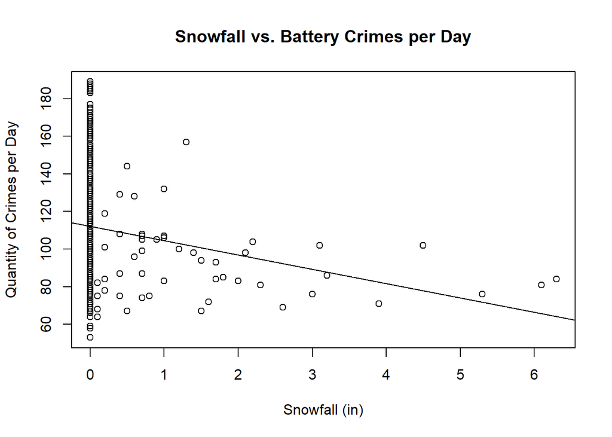

```r
plot(battery_data$SNOW, battery_data$n, main="Snowfall vs. Battery Crimes per Day", xlab="Snowfall (in)", ylab="Quantity of Crimes per Day")
abline(snow_battery_model)
```

```r
rain_battery_model = lm(n ~ PRCP, data = battery_data)
summary(rain_battery_model)
```

```
##
## Call:
## lm(formula = n ~ PRCP, data = battery_data)
##
## Residuals:
##    Min     1Q Median     3Q    Max
## -58.58 -16.58  -2.58  14.42  79.98
##
## Coefficients:
##             Estimate Std. Error t value Pr(>|t|)
## (Intercept) 111.5802     0.9463 117.916   <2e-16 ***
## PRCP         -1.3846     3.0689  -0.451    0.652
## ---
## Signif. codes:  0 '***' 0.001 '**' 0.01 '*' 0.05 '.' 0.1 ' ' 1
##
## Residual standard error: 24.41 on 733 degrees of freedom
## Multiple R-squared:  0.0002776,  Adjusted R-squared:  -0.001086
## F-statistic: 0.2036 on 1 and 733 DF,  p-value: 0.652
```

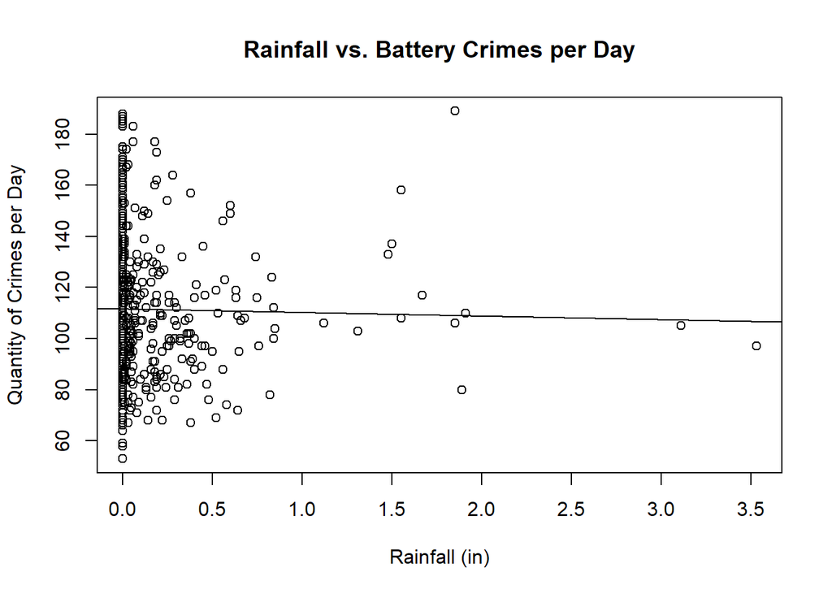

```r
plot(battery_data$PRCP, battery_data$n, main="Rainfall vs. Battery Crimes per Day", xlab="Rainfall (in)", ylab="Quantity of Crimes per Day")
abline(rain_battery_model)
```

```r
snow_theft_model = lm(n ~ SNOW, data = theft_data)
summary(snow_theft_model)
```

```
##
## Call:
## lm(formula = n ~ SNOW, data = theft_data)
##
## Residuals:
##     Min      1Q  Median      3Q     Max
## -66.472 -18.472  -1.472  16.028 109.528
##
## Coefficients:
##             Estimate Std. Error t value Pr(>|t|)
## (Intercept) 109.4725     0.9319 117.478  < 2e-16 ***
## SNOW         -8.6603     1.6797  -5.156 3.25e-07 ***
## ---
## Signif. codes:  0 '***' 0.001 '**' 0.01 '*' 0.05 '.' 0.1 ' ' 1
##
## Residual standard error: 24.83 on 733 degrees of freedom
## Multiple R-squared:  0.035,  Adjusted R-squared:  0.03368
## F-statistic: 26.58 on 1 and 733 DF,  p-value: 3.25e-07
```

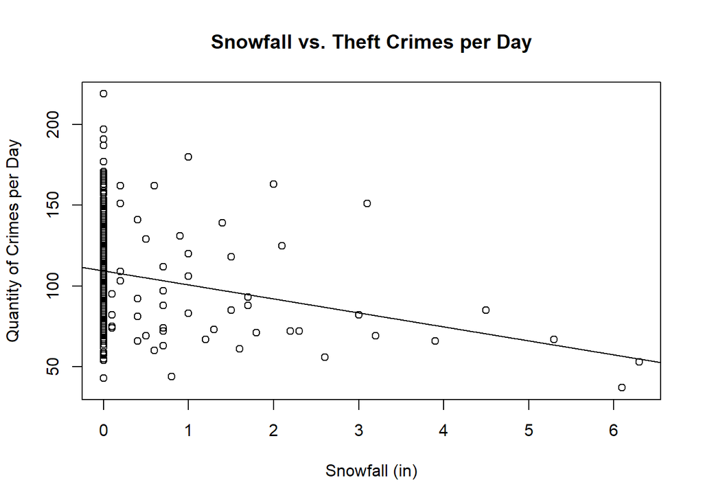

```r
plot(theft_data$SNOW, theft_data$n, main="Snowfall vs. Theft Crimes per Day", xlab="Snowfall (in)", ylab="Quantity of Crimes per Day")
abline(snow_theft_model)
```

```r
rain_theft_model = lm(n ~ PRCP, data = theft_data)
summary(rain_theft_model)
```

```
##
## Call:
## lm(formula = n ~ PRCP, data = theft_data)
##
## Residuals:
##    Min     1Q Median     3Q    Max
## -71.12 -18.05  -1.05  16.95 109.95
##
## Coefficients:
##             Estimate Std. Error t value Pr(>|t|)
## (Intercept) 109.0497     0.9782 111.480   <2e-16 ***
## PRCP         -4.8876     3.1725  -1.541    0.124
## ---
## Signif. codes:  0 '***' 0.001 '**' 0.01 '*' 0.05 '.' 0.1 ' ' 1
##
## Residual standard error: 25.24 on 733 degrees of freedom
## Multiple R-squared:  0.003228,   Adjusted R-squared:  0.001868
## F-statistic: 2.373 on 1 and 733 DF,  p-value: 0.1238
```

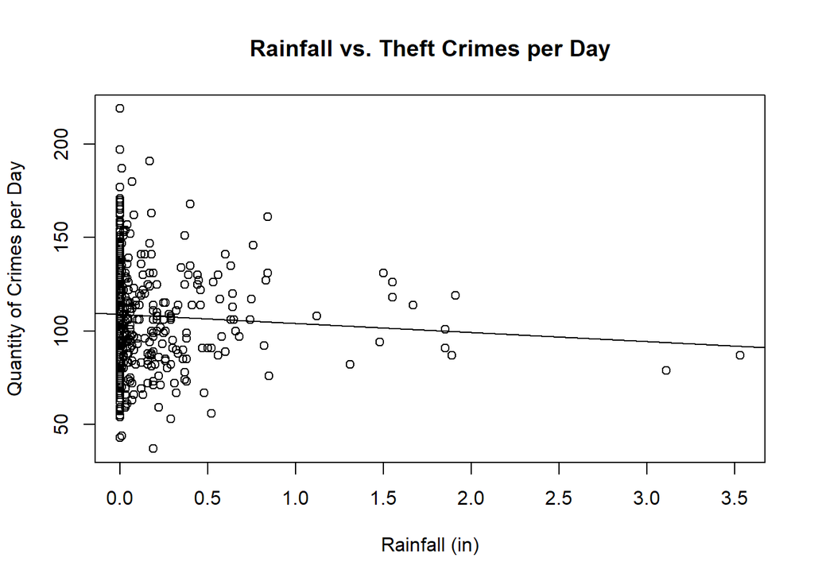

```r
plot(theft_data$PRCP, theft_data$n, main="Rainfall vs. Theft Crimes per Day", xlab="Rainfall (in)", ylab="Quantity of Crimes per Day")
abline(rain_theft_model)
```

These models help illustrate that we cannot definitively predict the amount of crimes with the amount of rainfall or snowfall; the means between the two groups are different, but we cannot predict on the amount of crimes.

### Testing a Random Forests model

Next, we wanted to try to utilize more of the discrete features within the weather data to see if we can predict other features, using a random forest predictor.

#### Predicting the crimes per day based on weather

First, we wanted to try predicting the crimes per day for battery and theft based on the weather data.

```r
partition_idx <- createDataPartition(battery_data$n, p = 0.75, list=FALSE)
training <- battery_data[partition_idx,]
test <- battery_data[-partition_idx,]

rf <- randomForest(
  n ~ . - `date(DateTime)` - `Primary Type`,
  data=training
)

print(rf)
```

```
##
## Call:
##  randomForest(formula = n ~ . - `date(DateTime)` - `Primary Type`,      data = training)
##                Type of random forest: regression
##                      Number of trees: 500
## No. of variables tried at each split: 13
##
##           Mean of squared residuals: 402.9122
##                     % Var explained: 29.26
```

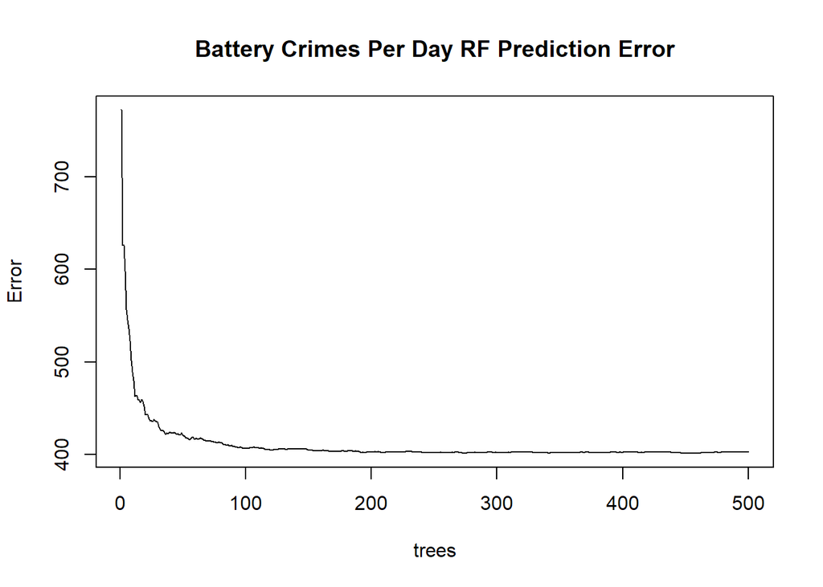

```r
plot(rf, main="Battery Crimes Per Day RF Prediction Error")
```

```r
partition_idx <- createDataPartition(theft_data$n, p = 0.75, list=FALSE)
training <- theft_data[partition_idx,]
test <- theft_data[-partition_idx,]

rf <- randomForest(
  n ~ . - `date(DateTime)` - `Primary Type`,
  data=training
)

print(rf)
```

```
##
## Call:
##  randomForest(formula = n ~ . - `date(DateTime)` - `Primary Type`,      data = training)
##                Type of random forest: regression
##                      Number of trees: 500
## No. of variables tried at each split: 13
##
##           Mean of squared residuals: 616.005
##                     % Var explained: 2.42
```

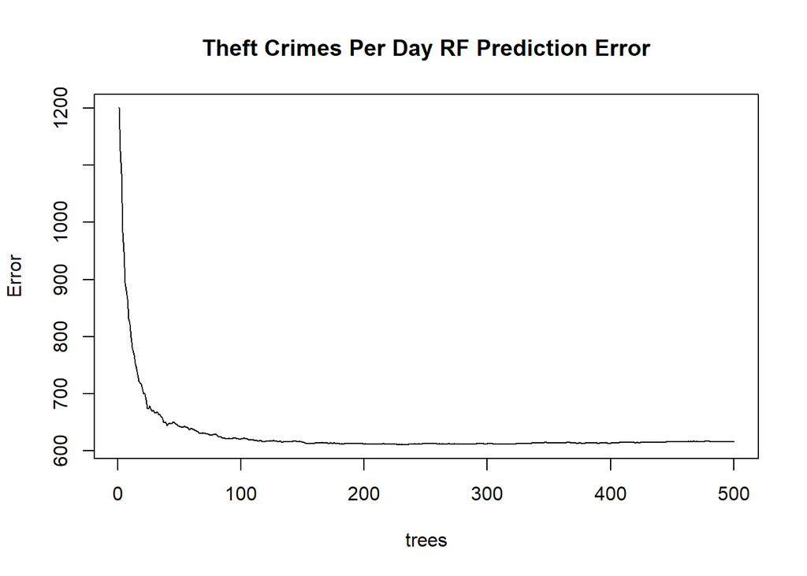

```r
plot(rf, main="Theft Crimes Per Day RF Prediction Error")
```

#### Predicting the average temperature per day based on weather and crimes

Next, we wanted to try to see whether or not the number of crimes could be a predictor for the average daily temperature

```r
partition_idx <- createDataPartition(battery_data$TAVG, p = 0.75, list=FALSE)
training <- battery_data[partition_idx,]
test <- battery_data[-partition_idx,]

rf1 <- randomForest(
  TAVG ~ . - `date(DateTime)` - `Primary Type` - n,
  data=training
)

print(rf1)
```

```
##
## Call:
##  randomForest(formula = TAVG ~ . - `date(DateTime)` - `Primary Type` -      n, data = training)
##                Type of random forest: regression
##                      Number of trees: 500
## No. of variables tried at each split: 13
##
##           Mean of squared residuals: 6.881229
##                     % Var explained: 98.11
```

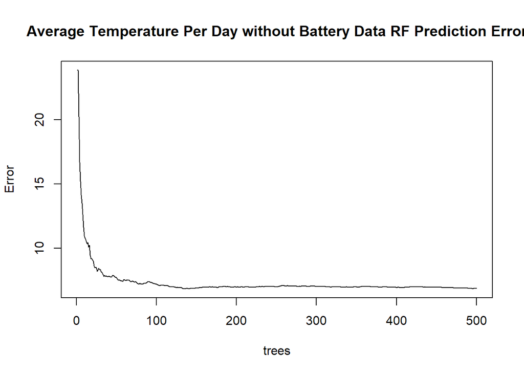

```r
plot(rf1, main="Average Temperature Per Day without Battery Data RF Prediction Error")
```

```r
rf2 <- randomForest(
  TAVG ~ . - `date(DateTime)` - `Primary Type`,
  data=training
)

print(rf2)
```

```
##
## Call:
##  randomForest(formula = TAVG ~ . - `date(DateTime)` - `Primary Type`,      data = training)
##                Type of random forest: regression
##                      Number of trees: 500
## No. of variables tried at each split: 13
##
##           Mean of squared residuals: 6.79417
##                     % Var explained: 98.13
```

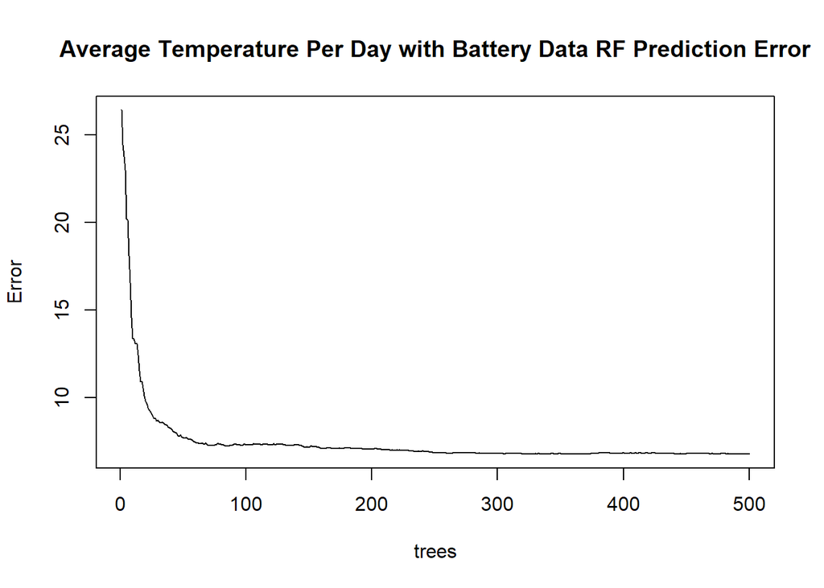

```r
plot(rf2, main="Average Temperature Per Day with Battery Data RF Prediction Error")
```

```r
rf3 <- randomForest(
  TAVG ~ n,
  data=training
)

print(rf3)
```

```
##
## Call:
##  randomForest(formula = TAVG ~ n, data = training)
##                Type of random forest: regression
##                      Number of trees: 500
## No. of variables tried at each split: 1
##
##           Mean of squared residuals: 283.7379
##                     % Var explained: 22.04
```

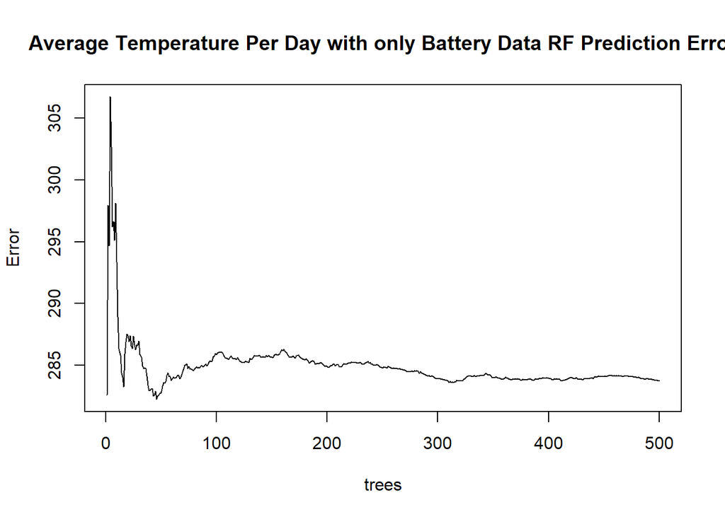

```r
plot(rf3, main="Average Temperature Per Day with only Battery Data RF Prediction Error")
```

```r
partition_idx <- createDataPartition(theft_data$TAVG, p = 0.75, list=FALSE)
training <- theft_data[partition_idx,]
test <- theft_data[-partition_idx,]

rf1 <- randomForest(
  TAVG ~ . - `date(DateTime)` - `Primary Type` - n,
  data=training
)

print(rf1)
```

```
##
## Call:
##  randomForest(formula = TAVG ~ . - `date(DateTime)` - `Primary Type` -      n, data = training)
##                Type of random forest: regression
##                      Number of trees: 500
## No. of variables tried at each split: 13
##
##           Mean of squared residuals: 7.287416
##                     % Var explained: 98
```

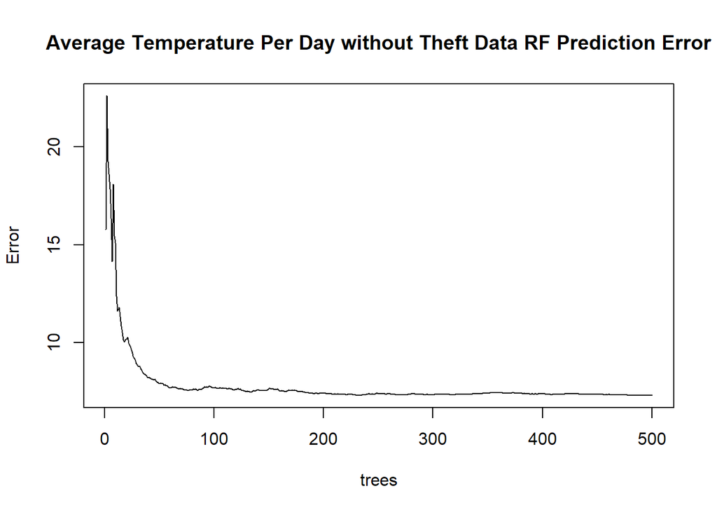

```r
plot(rf1, main="Average Temperature Per Day without Theft Data RF Prediction Error")
```

```r
rf2 <- randomForest(
  TAVG ~ . - `date(DateTime)` - `Primary Type`,
  data=training
)

print(rf2)
```

```
##
## Call:
##  randomForest(formula = TAVG ~ . - `date(DateTime)` - `Primary Type`,      data = training)
##                Type of random forest: regression
##                      Number of trees: 500
## No. of variables tried at each split: 13
##
##           Mean of squared residuals: 7.288122
##                     % Var explained: 98
```

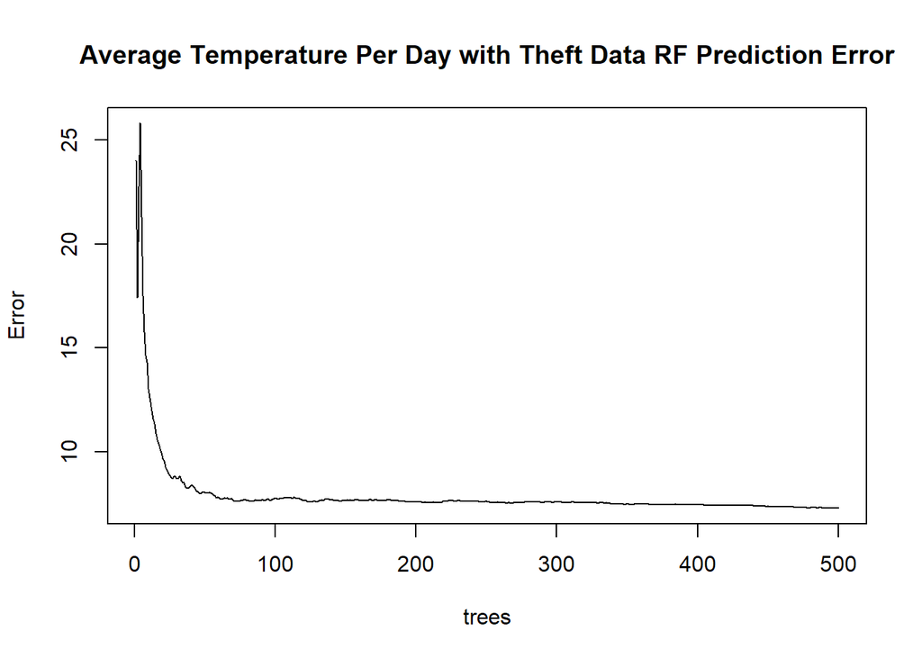

```r
plot(rf2, main="Average Temperature Per Day with Theft Data RF Prediction Error")
```

```r
rf3 <- randomForest(
  TAVG ~ n,
  data=training
)

print(rf3)
```

```
##
## Call:
##  randomForest(formula = TAVG ~ n, data = training)
##                Type of random forest: regression
##                      Number of trees: 500
## No. of variables tried at each split: 1
##
##           Mean of squared residuals: 327.4591
##                     % Var explained: 9.98
```

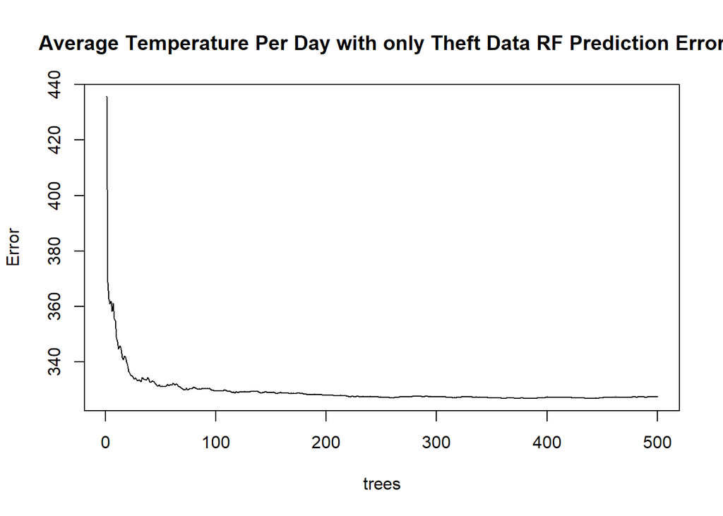

```r
plot(rf3, main="Average Temperature Per Day with only Theft Data RF Prediction Error")
```

These models show that while the number of crimes can have a slight improvement to the prediction of the daily average temperature, it is nearly insignificant in most cases.

#### Predicting the presence of fog on a day based on weather and crimes

Finally, we wanted to predict the presence of Fog (general weather feature likely in most inclement weather) based on the crimes per day.

```r
battery_data$Fog <- as.factor(battery_data$Fog)

partition_idx <- createDataPartition(battery_data$Fog, p = 0.75, list=FALSE)
training <- battery_data[partition_idx,]
test <- battery_data[-partition_idx,]

rf <- randomForest(
  Fog ~ n,
  data=training
)

print(rf)
```

```
##
## Call:
##  randomForest(formula = Fog ~ n, data = training)
##                Type of random forest: classification
##                      Number of trees: 500
## No. of variables tried at each split: 1
##
##         OOB estimate of  error rate: 34.24%
## Confusion matrix:
##     0  1 class.error
## 0 317 43   0.1194444
## 1 146 46   0.7604167
```

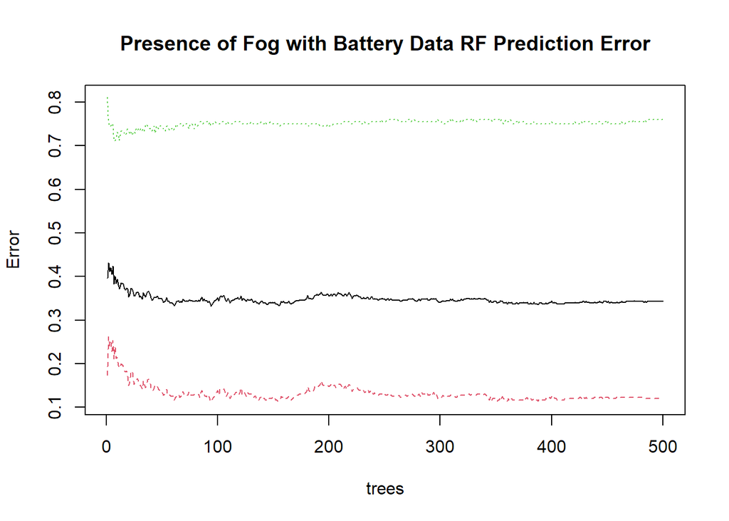

```r
plot(rf, main="Presence of Fog with Battery Data RF Prediction Error")
```

```r
theft_data$Fog <- as.factor(theft_data$Fog)

partition_idx <- createDataPartition(theft_data$Fog, p = 0.75, list=FALSE)
training <- theft_data[partition_idx,]
test <- theft_data[-partition_idx,]

rf <- randomForest(
  Fog ~ n,
  data=training
)

print(rf)
```

```
##
## Call:
##  randomForest(formula = Fog ~ n, data = training)
##                Type of random forest: classification
##                      Number of trees: 500
## No. of variables tried at each split: 1
##
##         OOB estimate of  error rate: 34.42%
## Confusion matrix:
##     0  1 class.error
## 0 296 64   0.1777778
## 1 126 66   0.6562500
```

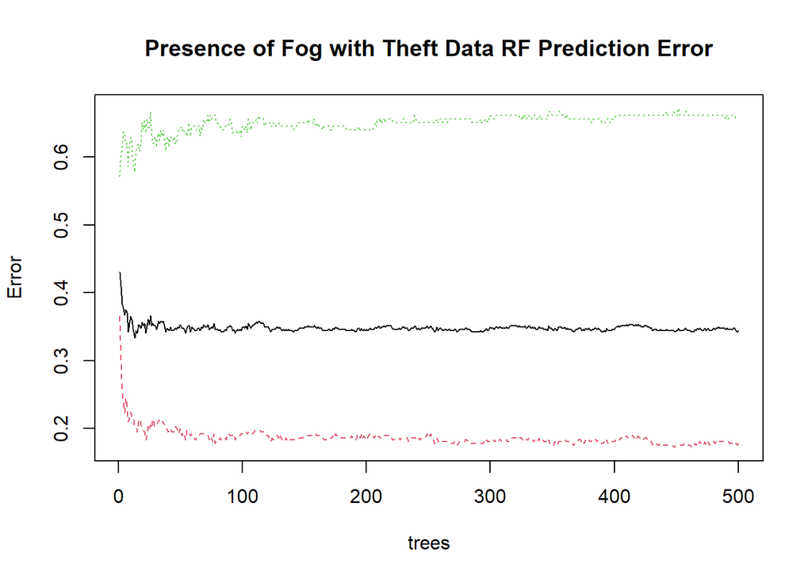

```r
plot(rf, main="Presence of Fog with Theft Data RF Prediction Error")
```

This data shows that we cannot definitively predict whether or not there is fog based on the number of crimes per day. While we are able to get some values, this is likely due to random chance.

## Results Analysis

We learned a lot about evaluating hypotheses during this project. Specifically, we had a few ideas of what to look for, but didn’t know what to expect. Through our analysis, we found that some of our hypotheses didn’t translate to models - making it impossible to generate predictions in some cases. We were able to learn a lot about testing different hypotheses, and working off of what was evaluated. For example, working on hypothesis 3, we figured out that we weren’t able to model on the data, however, we were able to derive additional tests (such as looking at the predictive capability of different features) to determine the composition and layout of the data.

We also were able to learn a lot about R through this assignment. Focusing more on statistical testing in R would have made different areas of this project much easier, but we all feel that we were able to pick up on the assignment relatively fast.